# Detection mode project - Analysis

Author

Martina Brayley

Published

June 26, 2024

# 1 Set up

The Master script links all parts of data preparation in 7 processing scripts. The code below excecutes the master file, running all 7 scripts within. The final product is the analytical dataset called an_df which combined all required variables from casummary, risk factors, mode of detection and mammographic density.

Data summary - commented out as output too large

```r
#skim(an_df)
```

```r
#dfSummary(an_df)
```

# 2 Preparation

Create lists of model variables as objects in the environment for easier manipulation.

Relevel reference groups within some exploratory variables.

Mammographic density is a special variable that will be used for subanalyses on cases with mammographic density only (to adjust for in the model)

**Note**

On 13/06/2024 discussed with Amy that it is probably better to use alchol units in the analyses instead of alcohol status or both. Looking back at L’s tables that seems to be the same as what was done originally.

### 2.0.1 Notes on missing values

There are no missing values in outcome as the analytical dataset was prepared by selecting cases with mode of detection which had to be either SD or I.

In v3 of script 7 error codes were recoded to NA as it is automatically handled in analysis. This dataset should be used. If error codes are of interest, rerun v2 of script 7 in master file, which will produce a dataset with error codes. The following code was written for data processed by v3 of script 7 where missing values are NA.

Even though NAs are automatically handled in glm(), to have better control over which rows are dropped and for consistency, they will be handled manually by the following steps for each model:

- select only the required variables for the specific model
- drop NAs using drop_na() function for all exposures and covariates in the model

The same steps will be then used to produce descriptive table (for publication Table 3) which will be merged with logistic regression results. Therefore, it is important that the number of observations are the same in the descriptive and analytical part of the table.

```r
an_df %>% tabyl(d_dmode_n)
```

| d_dmode_n | n | percent |
| --- | --- | --- |
| 0 | 1185 | 0.611 |
| 1 | 755 | 0.389 |

```r
# remove rows with missing error codes in specified columns
# error_codes <- c(888, 777)
#
# data <- an_df %>%
#   filter(!if_any(all_of(all_expl_variables), ~ . %in% error_codes))



# check numbers and percentages of missing values (coded out as output is too long)

# data %>%
#   map(pct_miss)
#
# data %>%
#   map(n_miss)
```

### 2.0.2 Relevel required categorical variables

Change the reference groups in the following categorical variables:

- BMI: reference = normal weight
- hormone receptor status (ER, PR) and HER2: reference = positive [releveled in script 7]

*BMI amended in this script directly before analysis as for descriptives the original level ordering will be needed*

```r
df <- an_df %>%
  mutate(d_bmi_entry_lab = fct_relevel(d_bmi_entry_lab, "18.5-25", "<18.5", "25-30", "30+")
  )
```

# 3 Univariate analysis

Repeat these steps for each exposure:

1. Tabulation including missing
2. Compute basic OR and chisqr test
3. Univariate logistic regression

**Important**

Code under the empty heading has been excluded from the html file as not relevant

## 3.1 Define function for univariate analysis

## 3.2 Compute univariate analysis

### 3.2.1 All cases

### 3.2.2 Cases with Breast density

## 3.3 Univariate analysis tables

**Note**

Comparing all cases vs cases with MD only

```r
# Univariate analysis with gtsummary

# all cases:
univ1 <- df %>%
  select(d_dmode_n, any_of(all_expl_variables)
         ) %>%
  tbl_uvregression(
    method = glm,
    y = d_dmode_n,
    method.args = list(family = binomial),
    exponentiate = TRUE,
    pvalue_fun = ~ style_pvalue(.x, digits = 2)
   ) %>%
  add_global_p() %>% # add global p-value
  add_nevent() %>% # add number of events of the outcome
  bold_labels() %>%
  modify_header(stat_nevent = "**Interval N**",
                stat_n = "**Total N**")

#univ1


# show_header_names(t1) # show header names to rename event N to Interval N


# MD cases only:
univ2 <- df %>%
  filter(d_md_avail == 1
  ) %>%
  select(d_dmode_n, any_of(all_expl_variables)
         ) %>%
  tbl_uvregression(
    method = glm,
    y = d_dmode_n,
    method.args = list(family = binomial),
    exponentiate = TRUE,
    pvalue_fun = ~ style_pvalue(.x, digits = 2)
   ) %>%
  add_global_p() %>% # add global p-value
  add_nevent() %>% # add number of events of the outcome
  bold_labels() %>%
  modify_header(stat_nevent = "**Interval N**",
                stat_n = "**Total N**")


# merge tables ---------------------------------------------------------------


#univariate <- tbl_merge(tbls = list(t1, t2))


univariate <- tbl_merge(
  tbls = list(univ1, univ2),
  tab_spanner = c("**All cases**", "**Cases with MD**")
   )

univariate
```

| **Characteristic** | **All cases** **Total N** | **All cases** **Interval N** | **All cases** **OR**<sup>1</sup> | **All cases** **95% CI**<sup>1</sup> | **All cases** **p-value** | **Cases with MD** **Total N** | **Cases with MD** **Interval N** | **Cases with MD** **OR**<sup>1</sup> | **Cases with MD** **95% CI**<sup>1</sup> | **Cases with MD** **p-value** |
| --- | --- | --- | --- | --- | --- | --- | --- | --- | --- | --- |
| d_R1menopause_lab3 | 1,940 | 755 |  |  | 0.33 | 1,191 | 401 |  |  | 0.054 |
| Premenopausal |  |  | — | — |  |  |  | — | — |  |
| Postmenopausal |  |  | 0.91 | 0.74, 1.10 |  |  |  | 0.75 | 0.56, 1.01 |  |
| d_age_menopause_lab | 1,935 | 754 |  |  | 0.10 | 1,186 | 400 |  |  | 0.015 |
| <50 |  |  | — | — |  |  |  | — | — |  |
| 51-53 |  |  | 1.06 | 0.83, 1.36 |  |  |  | 1.08 | 0.79, 1.48 |  |
| 53+ |  |  | 1.46 | 1.05, 2.03 |  |  |  | 1.66 | 1.11, 2.47 |  |
| Pre-menopausal |  |  | 1.21 | 0.94, 1.55 |  |  |  | 1.52 | 1.06, 2.19 |  |
| d_R1hrtstatus_lab | 1,932 | 752 |  |  | 0.015 | 1,186 | 399 |  |  | <0.001 |
| Never |  |  | — | — |  |  |  | — | — |  |
| Former |  |  | 1.06 | 0.81, 1.37 |  |  |  | 0.95 | 0.68, 1.32 |  |
| Current |  |  | 1.51 | 1.15, 1.98 |  |  |  | 1.77 | 1.27, 2.47 |  |
| Pre-menopausal |  |  | 1.26 | 1.0, 1.61 |  |  |  | 1.57 | 1.11, 2.21 |  |
| d_parity_lab | 1,940 | 755 |  |  | 0.86 | 1,191 | 401 |  |  | >0.99 |
| 0 |  |  | — | — |  |  |  | — | — |  |
| 1 |  |  | 1.14 | 0.79, 1.66 |  |  |  | 1.05 | 0.65, 1.72 |  |
| 2 |  |  | 1.07 | 0.81, 1.43 |  |  |  | 1.03 | 0.71, 1.50 |  |
| 3+ |  |  | 1.01 | 0.74, 1.39 |  |  |  | 1.02 | 0.67, 1.55 |  |
| d_agebirth1_lab | 1,933 | 753 |  |  | 0.85 | 1,185 | 399 |  |  | 0.82 |
| <20 |  |  | — | — |  |  |  | — | — |  |
| 20-24 |  |  | 0.82 | 0.51, 1.33 |  |  |  | 0.83 | 0.45, 1.61 |  |
| 25-29 |  |  | 0.78 | 0.49, 1.26 |  |  |  | 0.92 | 0.49, 1.74 |  |
| 30-34 |  |  | 0.90 | 0.55, 1.49 |  |  |  | 1.09 | 0.57, 2.15 |  |
| 35+ |  |  | 0.83 | 0.47, 1.49 |  |  |  | 1.04 | 0.48, 2.25 |  |
| Non-parous |  |  | 0.77 | 0.47, 1.29 |  |  |  | 0.90 | 0.46, 1.81 |  |
| d_age_menarche_lab | 1,760 | 691 |  |  | 0.19 | 1,086 | 361 |  |  | 0.29 |
| <12 |  |  | — | — |  |  |  | — | — |  |
| 12-13 |  |  | 1.20 | 0.94, 1.53 |  |  |  | 1.23 | 0.90, 1.68 |  |
| 14+ |  |  | 1.00 | 0.76, 1.32 |  |  |  | 1.00 | 0.70, 1.45 |  |
| d_ocstatus_lab | 1,937 | 754 |  |  | 0.21 | 1,189 | 400 |  |  | 0.15 |
| Never |  |  | — | — |  |  |  | — | — |  |
| Former |  |  | 1.27 | 0.97, 1.66 |  |  |  | 1.38 | 0.99, 1.94 |  |
| Current |  |  | 1.13 | 0.61, 2.05 |  |  |  | 1.73 | 0.43, 6.27 |  |
| d_bbd_lab | 1,940 | 755 |  |  | <0.001 | 1,191 | 401 |  |  | 0.029 |
| No |  |  | — | — |  |  |  | — | — |  |
| Yes |  |  | 1.45 | 1.19, 1.75 |  |  |  | 1.32 | 1.03, 1.70 |  |
| d_fambrca_lab | 1,940 | 755 |  |  | 0.049 | 1,191 | 401 |  |  | 0.20 |
| No |  |  | — | — |  |  |  | — | — |  |
| Yes |  |  | 1.24 | 1.00, 1.54 |  |  |  | 1.20 | 0.91, 1.60 |  |
| d_R1alcohol_units_lab | 1,940 | 755 |  |  | 0.45 | 1,191 | 401 |  |  | 0.74 |
| 0 |  |  | — | — |  |  |  | — | — |  |
| 1-9 |  |  | 1.09 | 0.84, 1.43 |  |  |  | 1.07 | 0.76, 1.53 |  |
| 10-19 |  |  | 1.24 | 0.95, 1.63 |  |  |  | 1.22 | 0.86, 1.75 |  |
| 20-29 |  |  | 1.15 | 0.85, 1.55 |  |  |  | 1.12 | 0.75, 1.67 |  |
| 30+ |  |  | 0.96 | 0.67, 1.36 |  |  |  | 0.93 | 0.58, 1.48 |  |
| d_R1smokingstatus_lab | 1,938 | 755 |  |  | 0.38 | 1,190 | 401 |  |  | 0.14 |
| Never |  |  | — | — |  |  |  | — | — |  |
| Former |  |  | 1.04 | 0.86, 1.27 |  |  |  | 1.14 | 0.88, 1.47 |  |
| Current |  |  | 0.78 | 0.52, 1.15 |  |  |  | 0.65 | 0.35, 1.13 |  |
| d_bmi_entry_lab | 1,919 | 748 |  |  | <0.001 | 1,175 | 395 |  |  | <0.001 |
| 18.5-25 |  |  | — | — |  |  |  | — | — |  |
| <18.5 |  |  | 3.48 | 1.00, 16.0 |  |  |  | 2.06 | 0.45, 10.5 |  |
| 25-30 |  |  | 0.65 | 0.53, 0.81 |  |  |  | 0.62 | 0.47, 0.82 |  |
| 30+ |  |  | 0.71 | 0.55, 0.92 |  |  |  | 0.55 | 0.39, 0.78 |  |
| d_R1physmet_leis_who_lab | 1,926 | 749 |  |  | 0.19 | 1,181 | 398 |  |  | 0.45 |
| <9 |  |  | — | — |  |  |  | — | — |  |
| 9-18 |  |  | 1.04 | 0.78, 1.39 |  |  |  | 0.92 | 0.63, 1.35 |  |
| 18+ |  |  | 1.21 | 0.96, 1.53 |  |  |  | 1.12 | 0.83, 1.51 |  |

<sup>1</sup> OR = Odds Ratio, CI = Confidence Interval

# 4 Test trick models

There are 3 groups of variables that require trick recoding (Tumour characteristics, parity related and menopause related). These variables are closely related and have 1 group within them that is the same in all of the variables. For example, if we look at the parity variables (binary parous, n of parous pregnancies, age at first birth), all 3 variables have a level of “non-parous” women, which all cannot be in the model. Therefore, to trick the model we recode the non-parous women in n of parous preg and age at first birth variables to the reference group. Although, it may seem counter intuitive, when the equation is written down including the indicator variables, the maths works.

When we run 2 models:

1. a model on a subset of parous women only and with the remaining 2 parity related variables
2. a model with all cases, the parous binary variable and the 2 recoded parity related variables (non parous women part of the reference group)

The estimates will be exactly the same. This needs to be tested for all 3 groups of these variables.

17/06/2024

Agreed with Amy and Montse to remove the binary parity variable from the model and only use n of pregnancied. The reference group will be 0 children.

## 4.1 Parity related variables

```r
# tabulate trick vars by parity to see if recoded properly -----------------------

## age at birth
df %>% tabyl(d_agebirth1_tr_lab, d_parity_lab) %>%
  adorn_title()
```

|  | d_parity_lab |  |  |  |
| --- | --- | --- | --- | --- |
| d_agebirth1_tr_lab | 0 | 1 | 2 | 3+ |
| <20 | 258 | 9 | 39 | 32 |
| 20-24 | 0 | 29 | 312 | 164 |
| 25-29 | 0 | 46 | 434 | 197 |
| 30-34 | 0 | 67 | 199 | 30 |
| 35+ | 0 | 60 | 51 | 6 |
|  | 0 | 0 | 3 | 4 |

```r
df %>% tabyl(d_agebirth1_lab, d_parity_lab) %>%
  adorn_title()
```

|  | d_parity_lab |  |  |  |
| --- | --- | --- | --- | --- |
| d_agebirth1_lab | 0 | 1 | 2 | 3+ |
| <20 | 0 | 9 | 39 | 32 |
| 20-24 | 0 | 29 | 312 | 164 |
| 25-29 | 0 | 46 | 434 | 197 |
| 30-34 | 0 | 67 | 199 | 30 |
| 35+ | 0 | 60 | 51 | 6 |
| Non-parous | 258 | 0 | 0 | 0 |
|  | 0 | 0 | 3 | 4 |

```r
df %>%  tabyl(d_parous_lab, d_parity_lab)
```

| d_parous_lab | 0 | 1 | 2 | 3+ |
| --- | --- | --- | --- | --- |
| Not parous | 258 | 0 | 0 | 0 |
| Parous | 0 | 211 | 1.04e+03 | 433 |

```r
## number of parous pregnancies
# df %>% tabyl(d_parity_tr_lab, d_parous_lab) %>%
#   adorn_title()
# df %>% tabyl(d_parity_lab, d_parous_lab) %>%
#   adorn_title()

# MODEL A - subset on parous women ------------------------------------------------

model <- df %>%
 filter(d_parity_lab != "0") %>%
  glm(formula = d_dmode_n ~ d_agebirth1_lab,
            family = binomial(link = "logit"))
#summary(model)
#logistic.display(model)

tbl_regression(model, exponentiate = TRUE) %>%
  add_n(location = "level") %>%
  add_nevent() %>%
  modify_header(stat_nevent = "**Interval N**",
                stat_n = "**Total N**")
```

| **Characteristic** | **Total N** | **Interval N** | **OR**<sup>1</sup> | **95% CI**<sup>1</sup> | **p-value** |
| --- | --- | --- | --- | --- | --- |
| d_agebirth1_lab |  | 656 |  |  |  |
| <20 | 80 |  | — | — |  |
| 20-24 | 505 |  | 0.82 | 0.51, 1.33 | 0.4 |
| 25-29 | 677 |  | 0.78 | 0.49, 1.26 | 0.3 |
| 30-34 | 296 |  | 0.90 | 0.55, 1.49 | 0.7 |
| 35+ | 117 |  | 0.83 | 0.47, 1.49 | 0.5 |

<sup>1</sup> OR = Odds Ratio, CI = Confidence Interval

```r
# MODEL B - binary parity status in the model -------------------------------------

model <- df %>%
  glm(formula = d_dmode_n ~  d_parity_lab + d_agebirth1_tr_lab,
            family = binomial(link = "logit"))
#summary(model)
#logistic.display(model)

tbl_regression(model, exponentiate = TRUE) %>%
  add_n(location = "level") %>%
  add_nevent() %>%
  modify_header(stat_nevent = "**Interval N**",
                stat_n = "**Total N**")
```

| **Characteristic** | **Total N** | **Interval N** | **OR**<sup>1</sup> | **95% CI**<sup>1</sup> | **p-value** |
| --- | --- | --- | --- | --- | --- |
| d_parity_lab |  | 753 |  |  |  |
| 0 | 258 |  | — | — |  |
| 1 | 211 |  | 1.37 | 0.76, 2.45 | 0.3 |
| 2 | 1,035 |  | 1.31 | 0.78, 2.20 | 0.3 |
| 3+ | 429 |  | 1.24 | 0.73, 2.11 | 0.4 |
| d_agebirth1_tr_lab |  | 753 |  |  |  |
| <20 | 338 |  | — | — |  |
| 20-24 | 505 |  | 0.82 | 0.51, 1.33 | 0.4 |
| 25-29 | 677 |  | 0.78 | 0.49, 1.25 | 0.3 |
| 30-34 | 296 |  | 0.88 | 0.53, 1.47 | 0.6 |
| 35+ | 117 |  | 0.80 | 0.44, 1.46 | 0.5 |

<sup>1</sup> OR = Odds Ratio, CI = Confidence Interval

**Note**

Trick on parity variables DISCUSS  
when binary parous status was in the model the estimates were exact now slightly different.

## 4.2 Menopause related variables

```r
# tabulate trick vars by parity to see if recoded properly

## age at menopause
df %>% tabyl(d_age_meno_tr_lab, d_R1menopause_lab3) %>%
  adorn_title()
```

|  | d_R1menopause_lab3 |  |
| --- | --- | --- |
| d_age_meno_tr_lab | Premenopausal | Postmenopausal |
| <50 | 597 | 443 |
| 51-53 | 0 | 678 |
| 53+ | 0 | 217 |
|  | 0 | 5 |

```r
## HRT use
df %>% tabyl(d_R1hrt_tr_lab, d_R1menopause_lab3) %>%
  adorn_title()
```

|  | d_R1menopause_lab3 |  |
| --- | --- | --- |
| d_R1hrt_tr_lab | Premenopausal | Postmenopausal |
| Never | 595 | 546 |
| Former | 0 | 442 |
| Current | 0 | 349 |
|  | 2 | 6 |

```r
# MODEL A - subset on postmenopausal  women ---------------------------------
model <- df %>%
  filter(d_R1menopause_cat3 == 1) %>%
  glm(formula = d_dmode_n ~ d_age_meno_tr_lab + d_R1hrt_tr_lab,
            family = binomial(link = "logit"))
#summary(model)
#logistic.display(model)

tbl_regression(model, exponentiate = TRUE) %>%
  add_n(location = "label") %>%
  add_nevent() %>%
  modify_header(stat_nevent = "**Interval N**",
                stat_n = "**Total N**")
```

| **Characteristic** | **Total N** | **Interval N** | **OR**<sup>1</sup> | **95% CI**<sup>1</sup> | **p-value** |
| --- | --- | --- | --- | --- | --- |
| d_age_meno_tr_lab | 1,332 | 509 |  |  |  |
| <50 |  |  | — | — |  |
| 51-53 |  |  | 1.05 | 0.82, 1.35 | 0.7 |
| 53+ |  |  | 1.56 | 1.12, 2.18 | 0.009 |
| d_R1hrt_tr_lab | 1,332 | 509 |  |  |  |
| Never |  |  | — | — |  |
| Former |  |  | 1.10 | 0.85, 1.44 | 0.5 |
| Current |  |  | 1.60 | 1.21, 2.12 | 0.001 |

<sup>1</sup> OR = Odds Ratio, CI = Confidence Interval

```r
# MODEL B - binary parity status in the model -------------------------------------

model <- df %>%
  glm(formula = d_dmode_n ~ d_R1menopause_lab3 + d_age_meno_tr_lab + d_R1hrt_tr_lab,
            family = binomial(link = "logit"))
#summary(model)
#logistic.display(model)

tbl_regression(model, exponentiate = TRUE) %>%
  add_n(location = "label") %>%
  add_nevent() %>%
  modify_header(stat_nevent = "**Interval N**",
                stat_n = "**Total N**")
```

| **Characteristic** | **Total N** | **Interval N** | **OR**<sup>1</sup> | **95% CI**<sup>1</sup> | **p-value** |
| --- | --- | --- | --- | --- | --- |
| d_R1menopause_lab3 | 1,927 | 751 |  |  |  |
| Premenopausal |  |  | — | — |  |
| Postmenopausal |  |  | 0.70 | 0.52, 0.93 | 0.015 |
| d_age_meno_tr_lab | 1,927 | 751 |  |  |  |
| <50 |  |  | — | — |  |
| 51-53 |  |  | 1.05 | 0.82, 1.35 | 0.7 |
| 53+ |  |  | 1.56 | 1.12, 2.18 | 0.009 |
| d_R1hrt_tr_lab | 1,927 | 751 |  |  |  |
| Never |  |  | — | — |  |
| Former |  |  | 1.10 | 0.85, 1.44 | 0.5 |
| Current |  |  | 1.60 | 1.21, 2.12 | 0.001 |

<sup>1</sup> OR = Odds Ratio, CI = Confidence Interval

**Note**

Trick on menopausae variables **SUCCESSFULL**

## 4.3 Tumour characteristics variables

All DCIS, including those with missing values in the variables below were coded as the reference group. This approach was done also by Louise. Assuming most DCIS would be missing so this seems correct.

```r
# tabulate trick vars by parity to see if recoded properly

## grade
df %>% tabyl(d_grade_tr, d_inv_status_lab) %>%
  adorn_title()
```

|  | d_inv_status_lab |  |
| --- | --- | --- |
| d_grade_tr | DCIS | Invasive |
| 1 | 308 | 338 |
| 2 | 0 | 812 |
| 3 | 0 | 451 |
|  | 0 | 31 |

```r
df %>% tabyl(d_grade_lab, d_inv_status_lab) %>%
  adorn_title()
```

|  | d_inv_status_lab |  |
| --- | --- | --- |
| d_grade_lab | DCIS | Invasive |
| 1 | 0 | 338 |
| 2 | 0 | 812 |
| 3 | 0 | 451 |
|  | 308 | 31 |

```r
## morphology
df %>% tabyl(d_morph4_tr_lab, d_inv_status_lab) %>%
  adorn_title()
```

|  | d_inv_status_lab |  |
| --- | --- | --- |
| d_morph4_tr_lab | DCIS | Invasive |
| Ductal | 308 | 1247 |
| Lobular | 0 | 214 |
| Mixed: ductal and other | 0 | 68 |
| Other | 0 | 103 |

```r
df %>% tabyl(d_morph4_lab, d_inv_status_lab) %>%
  adorn_title()
```

|  | d_inv_status_lab |  |
| --- | --- | --- |
| d_morph4_lab | DCIS | Invasive |
| Ductal | 0 | 1247 |
| Lobular | 0 | 214 |
| Mixed: ductal and other | 0 | 68 |
| Other | 0 | 103 |
|  | 308 | 0 |

```r
## positive nodes
df %>% tabyl(d_pos_nodes_tr_lab, d_inv_status_lab) %>%
  adorn_title()
```

|  | d_inv_status_lab |  |
| --- | --- | --- |
| d_pos_nodes_tr_lab | DCIS | Invasive |
| Negative | 308 | 905 |
| Positive | 0 | 428 |
|  | 0 | 299 |

```r
df %>% tabyl(d_pos_nodes_lab, d_inv_status_lab) %>%
  adorn_title()
```

|  | d_inv_status_lab |  |
| --- | --- | --- |
| d_pos_nodes_lab | DCIS | Invasive |
| Negative | 0 | 905 |
| Positive | 0 | 428 |
|  | 308 | 299 |

```r
## tumour size
df %>% tabyl(d_tmsize_tr_lab, d_inv_status_lab) %>%
  adorn_title()
```

|  | d_inv_status_lab |  |
| --- | --- | --- |
| d_tmsize_tr_lab | DCIS | Invasive |
| <21 | 308 | 992 |
| 21-50 | 0 | 387 |
| 50+ | 0 | 46 |
|  | 0 | 207 |

```r
df %>% tabyl(d_tumour_size_lab, d_inv_status_lab) %>%
  adorn_title()
```

|  | d_inv_status_lab |  |
| --- | --- | --- |
| d_tumour_size_lab | DCIS | Invasive |
| <21 | 0 | 992 |
| 21-50 | 0 | 387 |
| 50+ | 0 | 46 |
|  | 308 | 207 |

```r
## er status - reference positive
df %>% tabyl(d_er_tr_lab, d_inv_status_lab) %>%
  adorn_title()
```

|  | d_inv_status_lab |  |
| --- | --- | --- |
| d_er_tr_lab | DCIS | Invasive |
| Positive | 308 | 1316 |
| Negative | 0 | 224 |
|  | 0 | 92 |

```r
df %>% tabyl(d_er_status_lab, d_inv_status_lab) %>%
  adorn_title()
```

|  | d_inv_status_lab |  |
| --- | --- | --- |
| d_er_status_lab | DCIS | Invasive |
| Positive | 0 | 1316 |
| Negative | 0 | 224 |
|  | 308 | 92 |

```r
## pr status - reference positive
df %>% tabyl(d_pr_tr_lab, d_inv_status_lab) %>%
  adorn_title()
```

|  | d_inv_status_lab |  |
| --- | --- | --- |
| d_pr_tr_lab | DCIS | Invasive |
| Positive | 308 | 658 |
| Negative | 0 | 329 |
|  | 0 | 645 |

```r
df %>% tabyl(d_pr_status_lab, d_inv_status_lab) %>%
  adorn_title()
```

|  | d_inv_status_lab |  |
| --- | --- | --- |
| d_pr_status_lab | DCIS | Invasive |
| Positive | 0 | 658 |
| Negative | 0 | 329 |
|  | 308 | 645 |

```r
## her2 status - reference positive
df %>% tabyl(d_her2_tr_lab, d_inv_status_lab) %>%
  adorn_title()
```

|  | d_inv_status_lab |  |
| --- | --- | --- |
| d_her2_tr_lab | DCIS | Invasive |
| Positive | 308 | 194 |
| Negative | 0 | 1249 |
|  | 0 | 189 |

```r
df %>% tabyl(d_her2_status_lab, d_inv_status_lab) %>%
  adorn_title()
```

|  | d_inv_status_lab |  |
| --- | --- | --- |
| d_her2_status_lab | DCIS | Invasive |
| Positive | 0 | 194 |
| Negative | 0 | 1249 |
|  | 308 | 189 |

```r
# MODEL A - subset on postmenopausal  women ---------------------------------

# note: keeping morhology as categorical without labels as it affects the outpu

model <- df %>%
  filter(d_inv_status == 1) %>%
  glm(formula = d_dmode_n ~ d_grade_lab + d_morph4 + d_pos_nodes_lab + d_tumour_size + d_er_status + d_pr_status + d_her2_status,
            family = binomial(link = "logit"))
#summary(model)
#logistic.display(model)

tbl_regression(model, exponentiate = TRUE) %>%
  add_n(location = "level") %>%
  add_nevent() %>%
  modify_header(stat_nevent = "**Interval N**",
                stat_n = "**Total N**")
```

| **Characteristic** | **Total N** | **Interval N** | **OR**<sup>1</sup> | **95% CI**<sup>1</sup> | **p-value** |
| --- | --- | --- | --- | --- | --- |
| d_grade_lab |  | 289 |  |  |  |
| 1 | 122 |  | — | — |  |
| 2 | 336 |  | 1.32 | 0.81, 2.16 | 0.3 |
| 3 | 212 |  | 2.78 | 1.58, 4.96 | <0.001 |
| d_morph4 |  | 289 |  |  |  |
| 1 | 520 |  | — | — |  |
| 2 | 82 |  | 0.93 | 0.54, 1.59 | 0.8 |
| 3 | 32 |  | 1.31 | 0.61, 2.76 | 0.5 |
| 4 | 36 |  | 0.54 | 0.23, 1.21 | 0.2 |
| d_pos_nodes_lab |  | 289 |  |  |  |
| Negative | 444 |  | — | — |  |
| Positive | 226 |  | 1.57 | 1.09, 2.25 | 0.015 |
| d_tumour_size |  | 289 |  |  |  |
| 1 | 458 |  | — | — |  |
| 2 | 185 |  | 1.85 | 1.25, 2.72 | 0.002 |
| 3 | 27 |  | 2.00 | 0.84, 4.90 | 0.12 |
| d_er_status |  | 289 |  |  |  |
| 1 | 552 |  | — | — |  |
| 0 | 118 |  | 1.16 | 0.65, 2.05 | 0.6 |
| d_pr_status |  | 289 |  |  |  |
| 1 | 456 |  | — | — |  |
| 0 | 214 |  | 0.98 | 0.62, 1.54 | >0.9 |
| d_her2_status |  | 289 |  |  |  |
| 1 | 82 |  | — | — |  |
| 0 | 588 |  | 1.18 | 0.70, 2.01 | 0.5 |

<sup>1</sup> OR = Odds Ratio, CI = Confidence Interval

```r
# MODEL B - binary parity status in the model -------------------------------------

model <- df %>%
  glm(formula = d_dmode_n ~ d_inv_status + d_grade_tr + d_morph4_tr + d_pos_nodes_tr_lab + d_tmsize_tr_lab + d_er_tr_lab + d_pr_tr_lab + d_her2_tr_lab,
            family = binomial(link = "logit"))

#summary(model)
#logistic.display(model)

tbl_regression(model, exponentiate = TRUE) %>%
  add_n(location = "level") %>%
  add_nevent() %>%
  modify_header(stat_nevent = "**Interval N**",
                stat_n = "**Total N**")
```

| **Characteristic** | **Total N** | **Interval N** | **OR**<sup>1</sup> | **95% CI**<sup>1</sup> | **p-value** |
| --- | --- | --- | --- | --- | --- |
| d_inv_status |  | 336 |  |  |  |
| 1 | 670 |  | — | — |  |
| 0 | 308 |  | 0.63 | 0.30, 1.33 | 0.2 |
| d_grade_tr |  | 336 |  |  |  |
| 1 | 430 |  | — | — |  |
| 2 | 336 |  | 1.32 | 0.81, 2.16 | 0.3 |
| 3 | 212 |  | 2.78 | 1.58, 4.96 | <0.001 |
| d_morph4_tr |  | 336 |  |  |  |
| 1 | 828 |  | — | — |  |
| 2 | 82 |  | 0.93 | 0.54, 1.59 | 0.8 |
| 3 | 32 |  | 1.31 | 0.61, 2.76 | 0.5 |
| 4 | 36 |  | 0.54 | 0.23, 1.21 | 0.2 |
| d_pos_nodes_tr_lab |  | 336 |  |  |  |
| Negative | 752 |  | — | — |  |
| Positive | 226 |  | 1.57 | 1.09, 2.25 | 0.015 |
| d_tmsize_tr_lab |  | 336 |  |  |  |
| <21 | 766 |  | — | — |  |
| 21-50 | 185 |  | 1.85 | 1.25, 2.72 | 0.002 |
| 50+ | 27 |  | 2.00 | 0.84, 4.90 | 0.12 |
| d_er_tr_lab |  | 336 |  |  |  |
| Positive | 860 |  | — | — |  |
| Negative | 118 |  | 1.16 | 0.65, 2.05 | 0.6 |
| d_pr_tr_lab |  | 336 |  |  |  |
| Positive | 764 |  | — | — |  |
| Negative | 214 |  | 0.98 | 0.62, 1.54 | >0.9 |
| d_her2_tr_lab |  | 336 |  |  |  |
| Positive | 390 |  | — | — |  |
| Negative | 588 |  | 1.18 | 0.70, 2.01 | 0.5 |

<sup>1</sup> OR = Odds Ratio, CI = Confidence Interval

**Note**

Trick on Tumour characteristics variables **SUCCESSFULL**

## 4.4 Conclusion of trick test

# 5 Multivariate analysis

This is for the main analysis, subanalyses will be an independent section

The main analysis is comprised of 2 parts:

1. Examining the relationship between risk factors and mode of detection
2. Adjusting for mammographic density in a subset of cases with density available

## 5.1 Part 1: Relationship between risk factors and mode of detection

An analysis with all selected exposures in the model (adjusted for each other). Also, will need to adjust for time and age variables. Then, adjust for tumour characteristics and explore the difference. If there is no or minimal difference the model adjusted for tumour characteristics will be presented in the supplement.

Therefore, part 1 of the multivariate analysis will include 3 models:

1. Minimally adjusted - including all risk factor exposures
2. Adjusted for time variables
3. Fully adjusted - time variables and tumour characteristics.

**Model 1**: “d_R1alcohol_status_cat”, “d_R1alcohol_units_cat”, “d_R1smokingstatus_cat”, “d_bmi_entry_cat”, “d_R1physmet_leis_who”, “d_bbd”, “d_fambrca”, “d_age_menarche_cat”, “d_ocstatus_cat”, “d_R1menopause_cat3”, “d_age_menopause_cat”, “d_R1hrtstatus_cat”, “d_parous_cat”, “d_parity_cat”, “d_agebirth1_cat”

**Model 2**: Model 1 + “diagage”, “d_R1toBC_y”

**Model 3**: subset of those with TC! Model 1 + “diagage”, “d_R1toBC_y”,

**Model 4**: Model 3 + “d_inv_status”, “d_grade_cat”, “d_morph4”, “d_pos_nodes_cat”, “d_tumour_size”, “d_er_status”, “d_pr_status”, “d_her2_status”

### 5.1.1 Code

```r
# Model 1 -----------------------------------------------------------
# include parity and meno trick variable instead of original variables

model <- df %>%
  tidyr::drop_na(all_of(all_expl_variables_tr), diagage, d_R1toBC_y # excluding missing also from covariates as these are included in model 2  (to be comparable with model 2)
  ) %>%
  glm(formula = d_dmode_n ~ d_R1menopause_lab3 + d_age_meno_tr_lab
      + d_R1hrt_tr_lab
      + d_parity_lab + d_agebirth1_tr_lab + d_age_menarche_lab + d_ocstatus_lab
      + d_bbd_lab + d_fambrca_lab
      + d_R1alcohol_units_lab + d_R1smokingstatus_lab
      + d_bmi_entry_lab + d_R1physmet_leis_who_lab,
            family = binomial(link = "logit"))

# summary(model)
#logistic.display(model)

# # display result as a tidy model table with OR
#  tidy_model <- model %>%
#    tidy(exponentiate = TRUE, conf.int = TRUE) %>%
#    mutate(OR = estimate) %>%
#    select(-estimate) %>%
#    select(term, OR, everything())
#  tidy_model

model1 <- tbl_regression(model, exponentiate = TRUE) %>%
  add_n(location = "level")  %>%
  add_nevent(location = "level") %>%
  add_global_p() %>%
  modify_header(stat_nevent = "**Interval N**",
                stat_n = "**Total N**")

 #model1

 # Model 2 ----------------------------------------------------------------
 # include parity and meno trick variable instead of original variables

model <- df %>%
   tidyr::drop_na(all_of(all_expl_variables_tr), diagage, d_R1toBC_y # excluding missing also from covariates as these are included in model 2  (to be comparable with model 2)
  ) %>%
  glm(formula = d_dmode_n ~ d_R1menopause_lab3 + d_age_meno_tr_lab
      + d_R1hrt_tr_lab
      + d_parity_lab + d_agebirth1_tr_lab + d_age_menarche_lab + d_ocstatus_lab
      + d_bbd_lab + d_fambrca_lab
      + d_R1alcohol_units_lab + d_R1smokingstatus_lab
      + d_bmi_entry_lab + d_R1physmet_leis_who_lab
      + diagage + d_R1toBC_y,
            family = binomial(link = "logit"))



# summary(model)
# logistic.display(model)

# display result as a tidy model table with OR
 # tidy_model <- model %>%
 #   tidy(exponentiate = TRUE, conf.int = TRUE) %>%
 #   mutate(OR = estimate) %>%
 #   select(-estimate) %>%
 #   select(term, OR, everything())
 # tidy_model

model2 <- tbl_regression(model, exponentiate = TRUE) %>%
  add_n(location = "level")  %>%
  add_nevent(location = "level") %>%
  add_global_p() %>%
  modify_header(stat_nevent = "**Interval N**",
                stat_n = "**Total N**")

#model2

# Model 3  ----------------------------------------------------------------
#same as model 2 but on the subset of those with TC

 # include parity and meno trick variable instead of original variables

# including "diagage", "d_R1toBC_y" - MD variables will be included in sub analysis




 model <- df %>%
   tidyr::drop_na(all_of(tumour_char_tr), all_of(all_expl_variables_tr), diagage, d_R1toBC_y
           ) %>%
  glm(formula = d_dmode_n ~ d_R1menopause_lab3 + d_age_meno_tr_lab
      + d_R1hrt_tr_lab
      + d_parity_lab + d_agebirth1_tr_lab + d_age_menarche_lab + d_ocstatus_lab
      + d_bbd_lab + d_fambrca_lab
      + d_R1alcohol_units_lab + d_R1smokingstatus_lab
      + d_bmi_entry_lab + d_R1physmet_leis_who_lab
      + diagage + d_R1toBC_y,
            family = binomial(link = "logit"))

# summary(model)
# logistic.display(model)

# display result as a tidy model table with OR
# tidy_model <- model %>%
#   tidy(exponentiate = TRUE, conf.int = TRUE) %>%
#   mutate(OR = estimate) %>%
#   select(-estimate) %>%
#   select(term, OR, everything())
# tidy_model

model3 <- tbl_regression(model, exponentiate = TRUE) %>%
  add_n(location = "level")  %>%
  add_nevent(location = "level") %>%
  add_global_p() %>%
  modify_header(stat_nevent = "**Interval N**",
                stat_n = "**Total N**")

#model3

# Model 4 ---------------------------------------------------------------------

# Adding TC trick variables

model <- df %>%
   tidyr::drop_na(all_of(tumour_char_tr), all_of(all_expl_variables_tr), diagage, d_R1toBC_y
           ) %>%
  glm(formula = d_dmode_n ~ d_R1menopause_lab3 + d_age_meno_tr_lab
      + d_R1hrt_tr_lab
      + d_parity_lab + d_agebirth1_tr_lab + d_age_menarche_lab + d_ocstatus_lab
      + d_bbd_lab + d_fambrca_lab
      + d_R1alcohol_units_lab + d_R1smokingstatus_lab
      + d_bmi_entry_lab + d_R1physmet_leis_who_lab
      + diagage + d_R1toBC_y
      + d_inv_status + d_grade_tr + d_morph4_tr + d_pos_nodes_tr_lab
      + d_tmsize_tr_lab + d_er_tr_lab + d_pr_tr_lab + d_her2_tr_lab,
            family = binomial(link = "logit"))


# # find the problematic variable - adding 1 by 1
# model <- df %>%
#    tidyr::drop_na(all_of(tumour_char_tr), all_of(all_expl_variables_tr), diagage, d_R1toBC_y
#            ) %>%
#   glm(formula = d_dmode_n ~ d_R1menopause_lab3 + d_age_meno_tr_lab + d_R1hrt_tr_lab
#       + d_parity_lab + d_agebirth1_tr_lab + d_age_menarche_lab + d_ocstatus_lab
#       + d_bbd_lab + d_fambrca_lab
#       + d_R1alcohol_units_lab + d_R1smokingstatus_lab
#       + d_bmi_entry_lab + d_R1physmet_leis_who_lab + diagage + d_R1toBC_y
#       + d_inv_status,
#             family = binomial(link = "logit"))
#
#
#
# # try model with only inv_status
# model <- df %>%
#    tidyr::drop_na(all_of(tumour_char_tr), all_of(all_expl_variables_tr), diagage, d_R1toBC_y
#            ) %>%
#   glm(formula = d_dmode_n ~ d_inv_status,
#             family = binomial(link = "logit"))
#
#
# # it drops all 0s (dcis)
# df %>%
#   tidyr::drop_na(all_of(tumour_char_tr), all_of(all_expl_variables_tr), diagage, d_R1toBC_y
#                  ) %>%
#   tabyl(d_dmode_n, d_inv_status)
#
# # find out where the 0 in inv_status are dropping
# df %>%
#   tabyl(d_dmode_n, d_inv_status)
#
# # adding tumour variables to drop_na 1 by 1
# df %>%
#   tidyr::drop_na(d_inv_status, d_grade_tr, d_morph4_tr_lab, d_pos_nodes_tr_lab, d_tmsize_tr_lab, d_er_tr_lab, d_pr_tr_lab, d_her2_tr_lab) %>%
#   tabyl(d_dmode_n, d_inv_status)
#
#


# summary(model)
# logistic.display(model)


#display result as a tidy model table with OR
# tidy_model <- model %>%
#   tidy(exponentiate = TRUE, conf.int = TRUE) %>%
#   mutate(OR = round(estimate, 2),
#          std.error = round(std.error, 2),
#          p.value = round(p.value, 4),
#          conf.low = round(conf.low)
#          ) %>%
#   select(-estimate) %>%
#   select(term, OR, everything())
# tidy_model

model4 <- tbl_regression(model, exponentiate = TRUE) %>%
  add_n(location = "level")  %>%
  add_nevent(location = "level") %>%
  add_global_p() %>%
  modify_header(stat_nevent = "**Interval N**",
                stat_n = "**Total N**")

#model4
```

on 17/06 we’ve agreed to count al missing as missing in the trick model. Previously, if the missing were DCIS (e.g. dcis with missing ER status) they were recoded as the reference group (ER positive). However, when running the model with all original missing as missing in the trick variable with tumour characteristics (e.g. in the model adjusting for tumour characteristics) the number of DCIS was reduced to n = 1 as most missing in tumour variables are DCIS cases. Therefore, the model collapsed.

### 5.1.2 Tables

These tables are for internal purposes only.

**All cases**

*Minimally adjusted vs time and age adjusted*

Model 1 - Minimally adjusted - only for other exposures

Model 2 - adjusted for time from entry to BC and age at diagnosis

```r
# create table for model 1 and 2

model1and2 <- tbl_merge(
  tbls = list(model1, model2),
  tab_spanner = c("**Minimally adjusted**", "**Time and age adjusted**")
   )

model1and2
```

| **Characteristic** | **Minimally adjusted** **Total N** | **Minimally adjusted** **Interval N** | **Minimally adjusted** **OR**<sup>1</sup> | **Minimally adjusted** **95% CI**<sup>1</sup> | **Minimally adjusted** **p-value** | **Time and age adjusted** **Total N** | **Time and age adjusted** **Interval N** | **Time and age adjusted** **OR**<sup>1</sup> | **Time and age adjusted** **95% CI**<sup>1</sup> | **Time and age adjusted** **p-value** |
| --- | --- | --- | --- | --- | --- | --- | --- | --- | --- | --- |
| d_R1menopause_lab3 |  |  |  |  | 0.084 |  |  |  |  | 0.12 |
| Premenopausal | 519 | 209 | — | — |  | 519 | 209 | — | — |  |
| Postmenopausal | 1,188 | 465 | 0.75 | 0.54, 1.04 |  | 1,188 | 465 | 0.74 | 0.50, 1.09 |  |
| d_age_meno_tr_lab |  |  |  |  | 0.014 |  |  |  |  | 0.018 |
| <50 | 908 | 350 | — | — |  | 908 | 350 | — | — |  |
| 51-53 | 606 | 235 | 1.06 | 0.81, 1.39 |  | 606 | 235 | 1.04 | 0.79, 1.37 |  |
| 53+ | 193 | 89 | 1.68 | 1.17, 2.42 |  | 193 | 89 | 1.66 | 1.14, 2.42 |  |
| d_R1hrt_tr_lab |  |  |  |  | 0.034 |  |  |  |  | 0.020 |
| Never | 996 | 382 | — | — |  | 996 | 382 | — | — |  |
| Former | 393 | 146 | 1.09 | 0.81, 1.45 |  | 393 | 146 | 1.09 | 0.81, 1.47 |  |
| Current | 318 | 146 | 1.48 | 1.09, 2.02 |  | 318 | 146 | 1.53 | 1.12, 2.10 |  |
| d_parity_lab |  |  |  |  | 0.7 |  |  |  |  | 0.7 |
| 0 | 226 | 87 | — | — |  | 226 | 87 | — | — |  |
| 1 | 184 | 75 | 1.44 | 0.76, 2.72 |  | 184 | 75 | 1.48 | 0.77, 2.81 |  |
| 2 | 917 | 366 | 1.36 | 0.77, 2.39 |  | 917 | 366 | 1.35 | 0.76, 2.39 |  |
| 3+ | 380 | 146 | 1.31 | 0.73, 2.32 |  | 380 | 146 | 1.31 | 0.73, 2.34 |  |
| d_agebirth1_tr_lab |  |  |  |  | 0.5 |  |  |  |  | 0.4 |
| <20 | 299 | 120 | — | — |  | 299 | 120 | — | — |  |
| 20-24 | 444 | 180 | 0.82 | 0.49, 1.37 |  | 444 | 180 | 0.82 | 0.48, 1.38 |  |
| 25-29 | 604 | 227 | 0.68 | 0.41, 1.14 |  | 604 | 227 | 0.68 | 0.41, 1.15 |  |
| 30-34 | 260 | 109 | 0.81 | 0.47, 1.41 |  | 260 | 109 | 0.82 | 0.47, 1.44 |  |
| 35+ | 100 | 38 | 0.68 | 0.36, 1.31 |  | 100 | 38 | 0.70 | 0.36, 1.34 |  |
| d_age_menarche_lab |  |  |  |  | 0.061 |  |  |  |  | 0.065 |
| <12 | 401 | 149 | — | — |  | 401 | 149 | — | — |  |
| 12-13 | 863 | 360 | 1.19 | 0.93, 1.54 |  | 863 | 360 | 1.18 | 0.92, 1.53 |  |
| 14+ | 443 | 165 | 0.90 | 0.67, 1.21 |  | 443 | 165 | 0.89 | 0.66, 1.20 |  |
| d_ocstatus_lab |  |  |  |  | 0.3 |  |  |  |  | 0.4 |
| Never | 244 | 85 | — | — |  | 244 | 85 | — | — |  |
| Former | 1,417 | 571 | 1.25 | 0.93, 1.69 |  | 1,417 | 571 | 1.22 | 0.90, 1.67 |  |
| Current | 46 | 18 | 1.22 | 0.61, 2.41 |  | 46 | 18 | 1.18 | 0.58, 2.36 |  |
| d_bbd_lab |  |  |  |  | <0.001 |  |  |  |  | <0.001 |
| No | 1,124 | 410 | — | — |  | 1,124 | 410 | — | — |  |
| Yes | 583 | 264 | 1.48 | 1.20, 1.82 |  | 583 | 264 | 1.47 | 1.19, 1.82 |  |
| d_fambrca_lab |  |  |  |  | 0.020 |  |  |  |  | 0.019 |
| No | 1,310 | 498 | — | — |  | 1,310 | 498 | — | — |  |
| Yes | 397 | 176 | 1.32 | 1.04, 1.67 |  | 397 | 176 | 1.33 | 1.05, 1.68 |  |
| d_R1alcohol_units_lab |  |  |  |  | 0.3 |  |  |  |  | 0.3 |
| 0 | 357 | 132 | — | — |  | 357 | 132 | — | — |  |
| 1-9 | 464 | 180 | 1.05 | 0.78, 1.41 |  | 464 | 180 | 1.06 | 0.79, 1.43 |  |
| 10-19 | 435 | 188 | 1.27 | 0.94, 1.71 |  | 435 | 188 | 1.27 | 0.94, 1.71 |  |
| 20-29 | 274 | 111 | 1.06 | 0.76, 1.49 |  | 274 | 111 | 1.05 | 0.75, 1.48 |  |
| 30+ | 177 | 63 | 0.86 | 0.58, 1.28 |  | 177 | 63 | 0.87 | 0.58, 1.30 |  |
| d_R1smokingstatus_lab |  |  |  |  | 0.7 |  |  |  |  | 0.6 |
| Never | 1,024 | 407 | — | — |  | 1,024 | 407 | — | — |  |
| Former | 573 | 228 | 1.01 | 0.81, 1.26 |  | 573 | 228 | 1.01 | 0.81, 1.27 |  |
| Current | 110 | 39 | 0.83 | 0.54, 1.26 |  | 110 | 39 | 0.81 | 0.53, 1.24 |  |
| d_bmi_entry_lab |  |  |  |  | 0.004 |  |  |  |  | 0.006 |
| 18.5-25 | 883 | 383 | — | — |  | 883 | 383 | — | — |  |
| <18.5 | 9 | 6 | 2.89 | 0.73, 14.1 |  | 9 | 6 | 2.99 | 0.77, 14.5 |  |
| 25-30 | 528 | 184 | 0.70 | 0.55, 0.88 |  | 528 | 184 | 0.71 | 0.56, 0.89 |  |
| 30+ | 287 | 101 | 0.75 | 0.56, 1.01 |  | 287 | 101 | 0.76 | 0.57, 1.02 |  |
| d_R1physmet_leis_who_lab |  |  |  |  | 0.5 |  |  |  |  | 0.4 |
| <9 | 377 | 145 | — | — |  | 377 | 145 | — | — |  |
| 9-18 | 339 | 125 | 0.92 | 0.68, 1.26 |  | 339 | 125 | 0.89 | 0.65, 1.22 |  |
| 18+ | 991 | 404 | 1.08 | 0.84, 1.39 |  | 991 | 404 | 1.06 | 0.82, 1.37 |  |
| diagage |  |  |  |  |  | 1,707 | 674 | 1.02 | 0.99, 1.04 | 0.2 |
| d_R1toBC_y |  |  |  |  |  | 1,707 | 674 | 1.07 | 1.03, 1.10 | <0.001 |

<sup>1</sup> OR = Odds Ratio, CI = Confidence Interval

**Summary**

No changes in estimates after adjusting for age at diagnosis and time from entry to diagnosis

**Cases with TC**

**Adjusting for tumour characteristics**

Model 3 - model 2 (adjusted model) on subset of cases with TC

Model 4 - adjusting for TC

```r
model3and4 <- tbl_merge(
  tbls = list(model3, model4),
  tab_spanner = c("**Time and age adjusted**", "**Adjusted for TC**")
   )

model3and4
```

| **Characteristic** | **Time and age adjusted** **Total N** | **Time and age adjusted** **Interval N** | **Time and age adjusted** **OR**<sup>1</sup> | **Time and age adjusted** **95% CI**<sup>1</sup> | **Time and age adjusted** **p-value** | **Adjusted for TC** **Total N** | **Adjusted for TC** **Interval N** | **Adjusted for TC** **OR**<sup>1</sup> | **Adjusted for TC** **95% CI**<sup>1</sup> | **Adjusted for TC** **p-value** |
| --- | --- | --- | --- | --- | --- | --- | --- | --- | --- | --- |
| d_R1menopause_lab3 |  |  |  |  | 0.4 |  |  |  |  | 0.7 |
| Premenopausal | 264 | 96 | — | — |  | 264 | 96 | — | — |  |
| Postmenopausal | 592 | 202 | 0.77 | 0.43, 1.37 |  | 592 | 202 | 0.87 | 0.45, 1.67 |  |
| d_age_meno_tr_lab |  |  |  |  | 0.11 |  |  |  |  | 0.075 |
| <50 | 461 | 160 | — | — |  | 461 | 160 | — | — |  |
| 51-53 | 296 | 98 | 0.94 | 0.63, 1.41 |  | 296 | 98 | 0.82 | 0.53, 1.29 |  |
| 53+ | 99 | 40 | 1.62 | 0.94, 2.80 |  | 99 | 40 | 1.62 | 0.88, 3.00 |  |
| d_R1hrt_tr_lab |  |  |  |  | 0.023 |  |  |  |  | 0.018 |
| Never | 504 | 171 | — | — |  | 504 | 171 | — | — |  |
| Former | 196 | 59 | 1.01 | 0.64, 1.60 |  | 196 | 59 | 1.03 | 0.62, 1.71 |  |
| Current | 156 | 68 | 1.76 | 1.12, 2.79 |  | 156 | 68 | 1.95 | 1.18, 3.25 |  |
| d_parity_lab |  |  |  |  | 0.8 |  |  |  |  | 0.7 |
| 0 | 116 | 39 | — | — |  | 116 | 39 | — | — |  |
| 1 | 92 | 33 | 1.42 | 0.55, 3.64 |  | 92 | 33 | 1.32 | 0.45, 3.78 |  |
| 2 | 451 | 156 | 1.38 | 0.60, 3.13 |  | 451 | 156 | 1.08 | 0.42, 2.71 |  |
| 3+ | 197 | 70 | 1.46 | 0.63, 3.39 |  | 197 | 70 | 1.33 | 0.52, 3.39 |  |
| d_agebirth1_tr_lab |  |  |  |  | 0.7 |  |  |  |  | 0.5 |
| <20 | 152 | 55 | — | — |  | 152 | 55 | — | — |  |
| 20-24 | 216 | 74 | 0.69 | 0.32, 1.49 |  | 216 | 74 | 0.51 | 0.22, 1.21 |  |
| 25-29 | 309 | 105 | 0.64 | 0.31, 1.37 |  | 309 | 105 | 0.60 | 0.26, 1.40 |  |
| 30-34 | 126 | 47 | 0.79 | 0.35, 1.79 |  | 126 | 47 | 0.74 | 0.30, 1.86 |  |
| 35+ | 53 | 17 | 0.59 | 0.23, 1.54 |  | 53 | 17 | 0.55 | 0.18, 1.62 |  |
| d_age_menarche_lab |  |  |  |  | 0.2 |  |  |  |  | 0.4 |
| <12 | 198 | 68 | — | — |  | 198 | 68 | — | — |  |
| 12-13 | 425 | 155 | 1.11 | 0.76, 1.62 |  | 425 | 155 | 1.10 | 0.72, 1.70 |  |
| 14+ | 233 | 75 | 0.80 | 0.52, 1.24 |  | 233 | 75 | 0.85 | 0.52, 1.38 |  |
| d_ocstatus_lab |  |  |  |  | 0.3 |  |  |  |  | 0.3 |
| Never | 95 | 24 | — | — |  | 95 | 24 | — | — |  |
| Former | 743 | 267 | 1.48 | 0.88, 2.56 |  | 743 | 267 | 1.61 | 0.90, 2.92 |  |
| Current | 18 | 7 | 1.83 | 0.56, 5.71 |  | 18 | 7 | 1.45 | 0.38, 5.27 |  |

[output cut: 55 more lines]

<sup>1</sup> OR = Odds Ratio, CI = Confidence Interval

**Summary**

Relatively large changes in estimates for

- BMI category <18.5kg/m2 (underweight), although the confidence interval is very wide.
- Benign breast disease - stronger effect after adjusting for tumour characteristics.

## 5.2 Part 2: Adjusting for mammographic density

This part will require the same analysis as in part 1 on a **subset of cases with mamographic density**. Then expanding by a 4th model adjusting for mammographic density.

Not modelling TC here as the sample size would be significantly reduced.

**Model 5**: “d_R1alcohol_status_cat”, “d_R1alcohol_units_cat”, “d_R1smokingstatus_cat”, “d_bmi_entry_cat”, “d_R1physmet_leis_who”, “d_bbd”, “d_fambrca”, “d_age_menarche_cat”, “d_ocstatus_cat”, “d_R1menopause_cat3”, “d_age_menopause_cat”, “d_R1hrtstatus_cat”, “d_parous_cat”, “d_parity_cat”, “d_agebirth1_cat”

**Model 7**: Model 5 + “d_R1toMD_y”, “d_MDtoBC_y” [ decide whether to include all of these]

### 5.2.1 Code

```r
# Model 5 -----------------------------------------------------------
# include parity and meno trick variable instead of original variables

# only included alcohol status - check if we need to do the trick if including both
# relevel bmis so normal weight is the reference

model <- df %>%
  filter(d_md_avail == 1 # include only those with md
         ) %>%
  drop_na(all_of(all_expl_variables_tr), diagage, d_R1toBC_y
           ) %>%
  glm(formula = d_dmode_n ~ d_R1menopause_lab3 + d_age_meno_tr_lab
      + d_R1hrt_tr_lab
      + d_parity_lab + d_agebirth1_tr_lab + d_age_menarche_lab + d_ocstatus_lab
      + d_bbd_lab + d_fambrca_lab
      + d_R1alcohol_units_lab + d_R1smokingstatus_lab
      + d_bmi_entry_lab + d_R1physmet_leis_who_lab,
            family = binomial(link = "logit"))

# summary(model)
# logistic.display(model)

# display result as a tidy model table with OR
 # tidy_model <- model %>%
 #   tidy(exponentiate = TRUE, conf.int = TRUE) %>%
 #   mutate(OR = estimate) %>%
 #   select(-estimate) %>%
 #   select(term, OR, everything())
 # tidy_model

model5 <- tbl_regression(model, exponentiate = TRUE) %>%
  add_n(location = "level")  %>%
  add_nevent(location = "level") %>%
  add_global_p() %>%
  modify_header(stat_nevent = "**Interval N**",
                stat_n = "**Total N**")



 # Model 6 ----------------------------------------------------------------
 # include parity and meno trick variable instead of original variables

# only included alcohol status - check if we need to do the trick if including both
# including "diagage", "d_R1toBC_y" - MD variables will be included in sub analysis

model <- df %>%
   filter(d_md_avail == 1 # include only those with md
         ) %>%
   drop_na(all_of(all_expl_variables_tr), diagage, d_R1toBC_y
           ) %>%
  glm(formula = d_dmode_n ~ d_R1menopause_lab3 + d_age_meno_tr_lab
      + d_R1hrt_tr_lab
      + d_parity_lab + d_agebirth1_tr_lab + d_age_menarche_lab + d_ocstatus_lab
      + d_bbd_lab + d_fambrca_lab
      + d_R1alcohol_units_lab + d_R1smokingstatus_lab
      + d_bmi_entry_lab + d_R1physmet_leis_who_lab
      + diagage + d_R1toBC_y,
            family = binomial(link = "logit"))

# summary(model)
# logistic.display(model)

# # display result as a tidy model table with OR
#  tidy_model <- model %>%
#    tidy(exponentiate = TRUE, conf.int = TRUE) %>%
#    mutate(OR = estimate) %>%
#    select(-estimate) %>%
#    select(term, OR, everything())
#  tidy_model

model6 <- tbl_regression(model, exponentiate = TRUE) %>%
  add_n(location = "level")  %>%
  add_nevent(location = "level") %>%
  add_global_p() %>%
  modify_header(stat_nevent = "**Interval N**",
                stat_n = "**Total N**")
 # Model 7 ----------------------------------------------------------------
 # include parity and meno trick variable instead of original variables

# only included alcohol status - check if we need to do the trick if including both
# including "diagage", "d_R1toBC_y" and d_MDtoBC_y - not adjusted for R1toMD yet - discuss if needed

model <- df %>%
   filter(d_md_avail == 1 # include only those with md
         ) %>%
   drop_na(all_of(all_expl_variables_tr), diagage, d_R1toBC_y
           ) %>%
  glm(formula = d_dmode_n ~ d_R1alcohol_units_lab + d_R1menopause_lab3 + d_age_meno_tr_lab
      + d_R1hrt_tr_lab
      + d_parity_lab + d_agebirth1_tr_lab + d_age_menarche_lab + d_ocstatus_lab
      + d_bbd_lab + d_fambrca_lab
      + d_R1alcohol_units_lab + d_R1smokingstatus_lab
      + d_bmi_entry_lab + d_R1physmet_leis_who_lab
      + diagage + d_R1toBC_y + d_MDtoBC_y,
            family = binomial(link = "logit"))

# summary(model)
# logistic.display(model)

# # display result as a tidy model table with OR
#  tidy_model <- model %>%
#    tidy(exponentiate = TRUE, conf.int = TRUE) %>%
#    mutate(OR = estimate) %>%
#    select(-estimate) %>%
#    select(term, OR, everything())
#  tidy_model

model7 <- tbl_regression(model, exponentiate = TRUE) %>%
  add_n(location = "level")  %>%
  add_nevent(location = "level") %>%
  add_global_p() %>%
  modify_header(stat_nevent = "**Interval N**",
                stat_n = "**Total N**")

# Model 8 ----------------------------------------------------------------
 # include parity and meno trick variable instead of original variables

# only included alcohol status - check if we need to do the trick if including both
# including "diagage", "d_R1toBC_y" - MD variables will be included in sub analysis

model <- df %>%
   filter(d_md_avail == 1 # include only those with md
         ) %>%
  drop_na(all_of(all_expl_variables_tr), diagage, d_R1toBC_y
           ) %>%
  glm(formula = d_dmode_n ~ d_R1menopause_lab3 + d_age_meno_tr_lab
      + d_R1hrt_tr_lab
      + d_parity_lab + d_agebirth1_tr_lab + d_age_menarche_lab + d_ocstatus_lab
      + d_bbd_lab + d_fambrca_lab
      + d_R1alcohol_units_lab + d_R1smokingstatus_lab
      + d_bmi_entry_lab + d_R1physmet_leis_who_lab
      + diagage + d_R1toBC_y + d_MDtoBC_y
      + d_md_qrt,
            family = binomial(link = "logit"))

# summary(model)
# logistic.display(model)

# # display result as a tidy model table with OR
#  tidy_model <- model %>%
#    tidy(exponentiate = TRUE, conf.int = TRUE) %>%
#    mutate(OR = estimate) %>%
#    select(-estimate) %>%
#    select(term, OR, everything())
#  tidy_model

model8 <- tbl_regression(model, exponentiate = TRUE) %>%
  add_n(location = "level")  %>%
  add_nevent(location = "level") %>%
  add_global_p() %>%
  modify_header(stat_nevent = "**Interval N**",
                stat_n = "**Total N**")
```

### 5.2.2 Tables

This table is for internal purposes only.

```r
# combine results

model5to8 <- tbl_merge(
  tbls = list(model5, model6, model7, model8),
  tab_spanner = c("**Unadjusted**", "**Adjusted for DG age + entry to DG**", "**Adjusted for MDtoDG time**", "**Adjusted for MDtoDG time + MD**")
   )

model5to8
```

| **Characteristic** | **Unadjusted** **Total N** | **Unadjusted** **Interval N** | **Unadjusted** **OR**<sup>1</sup> | **Unadjusted** **95% CI**<sup>1</sup> | **Unadjusted** **p-value** | **Adjusted for DG age + entry to DG** **Total N** | **Adjusted for DG age + entry to DG** **Interval N** | **Adjusted for DG age + entry to DG** **OR**<sup>1</sup> | **Adjusted for DG age + entry to DG** **95% CI**<sup>1</sup> | **Adjusted for DG age + entry to DG** **p-value** | **Adjusted for MDtoDG time** **Total N** | **Adjusted for MDtoDG time** **Interval N** | **Adjusted for MDtoDG time** **OR**<sup>1</sup> | **Adjusted for MDtoDG time** **95% CI**<sup>1</sup> | **Adjusted for MDtoDG time** **p-value** | **Adjusted for MDtoDG time + MD** **Total N** | **Adjusted for MDtoDG time + MD** **Interval N** | **Adjusted for MDtoDG time + MD** **OR**<sup>1</sup> | **Adjusted for MDtoDG time + MD** **95% CI**<sup>1</sup> | **Adjusted for MDtoDG time + MD** **p-value** |
| --- | --- | --- | --- | --- | --- | --- | --- | --- | --- | --- | --- | --- | --- | --- | --- | --- | --- | --- | --- | --- |
| d_R1menopause_lab3 |  |  |  |  | 0.031 |  |  |  |  | 0.091 |  |  |  |  | 0.15 |  |  |  |  | 0.2 |
| Premenopausal | 199 | 74 | — | — |  | 199 | 74 | — | — |  | 199 | 74 | — | — |  | 199 | 74 | — | — |  |
| Postmenopausal | 847 | 274 | 0.60 | 0.38, 0.96 |  | 847 | 274 | 0.63 | 0.36, 1.08 |  | 847 | 274 | 0.67 | 0.39, 1.15 |  | 847 | 274 | 0.70 | 0.40, 1.22 |  |
| d_age_meno_tr_lab |  |  |  |  | 0.013 |  |  |  |  | 0.013 |  |  |  |  | 0.013 |  |  |  |  | 0.007 |
| <50 | 458 | 149 | — | — |  | 458 | 149 | — | — |  | 458 | 149 | — | — |  | 458 | 149 | — | — |  |
| 51-53 | 444 | 140 | 1.04 | 0.74, 1.48 |  | 444 | 140 | 1.04 | 0.73, 1.48 |  | 444 | 140 | 1.04 | 0.73, 1.48 |  | 444 | 140 | 1.04 | 0.73, 1.49 |  |
| 53+ | 144 | 59 | 1.86 | 1.19, 2.93 |  | 144 | 59 | 1.88 | 1.19, 2.97 |  | 144 | 59 | 1.88 | 1.19, 2.98 |  | 144 | 59 | 1.97 | 1.24, 3.14 |  |
| d_R1hrt_tr_lab |  |  |  |  | <0.001 |  |  |  |  | <0.001 |  |  |  |  | 0.001 |  |  |  |  | 0.006 |
| Never | 532 | 170 | — | — |  | 532 | 170 | — | — |  | 532 | 170 | — | — |  | 532 | 170 | — | — |  |
| Former | 286 | 81 | 1.08 | 0.75, 1.57 |  | 286 | 81 | 1.10 | 0.75, 1.61 |  | 286 | 81 | 1.09 | 0.74, 1.60 |  | 286 | 81 | 1.12 | 0.76, 1.64 |  |
| Current | 228 | 97 | 1.97 | 1.35, 2.90 |  | 228 | 97 | 1.99 | 1.36, 2.94 |  | 228 | 97 | 1.96 | 1.33, 2.90 |  | 228 | 97 | 1.84 | 1.24, 2.72 |  |
| d_parity_lab |  |  |  |  | >0.9 |  |  |  |  | >0.9 |  |  |  |  | >0.9 |  |  |  |  | >0.9 |
| 0 | 132 | 43 | — | — |  | 132 | 43 | — | — |  | 132 | 43 | — | — |  | 132 | 43 | — | — |  |
| 1 | 122 | 41 | 1.05 | 0.43, 2.49 |  | 122 | 41 | 1.06 | 0.43, 2.52 |  | 122 | 41 | 1.05 | 0.43, 2.52 |  | 122 | 41 | 1.16 | 0.47, 2.78 |  |
| 2 | 550 | 184 | 1.09 | 0.49, 2.35 |  | 550 | 184 | 1.09 | 0.49, 2.38 |  | 550 | 184 | 1.09 | 0.49, 2.36 |  | 550 | 184 | 1.21 | 0.54, 2.65 |  |
| 3+ | 242 | 80 | 1.13 | 0.50, 2.48 |  | 242 | 80 | 1.14 | 0.51, 2.51 |  | 242 | 80 | 1.14 | 0.51, 2.52 |  | 242 | 80 | 1.25 | 0.55, 2.77 |  |
| d_agebirth1_tr_lab |  |  |  |  | 0.8 |  |  |  |  | 0.8 |  |  |  |  | 0.8 |  |  |  |  | 0.8 |
| <20 | 174 | 58 | — | — |  | 174 | 58 | — | — |  | 174 | 58 | — | — |  | 174 | 58 | — | — |  |
| 20-24 | 285 | 91 | 0.89 | 0.44, 1.85 |  | 285 | 91 | 0.90 | 0.44, 1.87 |  | 285 | 91 | 0.90 | 0.45, 1.88 |  | 285 | 91 | 0.84 | 0.41, 1.75 |  |
| 25-29 | 372 | 120 | 0.87 | 0.43, 1.79 |  | 372 | 120 | 0.86 | 0.43, 1.79 |  | 372 | 120 | 0.87 | 0.43, 1.80 |  | 372 | 120 | 0.81 | 0.40, 1.69 |  |
| 30-34 | 155 | 59 | 1.14 | 0.54, 2.48 |  | 155 | 59 | 1.14 | 0.54, 2.48 |  | 155 | 59 | 1.14 | 0.54, 2.48 |  | 155 | 59 | 1.07 | 0.50, 2.33 |  |
| 35+ | 60 | 20 | 0.91 | 0.37, 2.23 |  | 60 | 20 | 0.90 | 0.37, 2.21 |  | 60 | 20 | 0.92 | 0.37, 2.26 |  | 60 | 20 | 0.89 | 0.36, 2.21 |  |
| d_age_menarche_lab |  |  |  |  | 0.14 |  |  |  |  | 0.14 |  |  |  |  | 0.14 |  |  |  |  | 0.2 |
| <12 | 257 | 79 | — | — |  | 257 | 79 | — | — |  | 257 | 79 | — | — |  | 257 | 79 | — | — |  |
| 12-13 | 520 | 185 | 1.22 | 0.87, 1.71 |  | 520 | 185 | 1.23 | 0.88, 1.72 |  | 520 | 185 | 1.22 | 0.87, 1.71 |  | 520 | 185 | 1.19 | 0.85, 1.67 |  |
| 14+ | 269 | 84 | 0.89 | 0.60, 1.32 |  | 269 | 84 | 0.89 | 0.60, 1.33 |  | 269 | 84 | 0.89 | 0.60, 1.32 |  | 269 | 84 | 0.87 | 0.58, 1.29 |  |
| d_ocstatus_lab |  |  |  |  | 0.6 |  |  |  |  | 0.7 |  |  |  |  | 0.6 |  |  |  |  | 0.6 |
| Never | 177 | 50 | — | — |  | 177 | 50 | — | — |  | 177 | 50 | — | — |  | 177 | 50 | — | — |  |
| Former | 859 | 294 | 1.21 | 0.83, 1.79 |  | 859 | 294 | 1.18 | 0.80, 1.75 |  | 859 | 294 | 1.20 | 0.82, 1.79 |  | 859 | 294 | 1.19 | 0.80, 1.78 |  |
| Current | 10 | 4 | 1.52 | 0.35, 5.93 |  | 10 | 4 | 1.49 | 0.34, 5.87 |  | 10 | 4 | 1.47 | 0.34, 5.78 |  | 10 | 4 | 1.51 | 0.35, 6.02 |  |
| d_bbd_lab |  |  |  |  | 0.023 |  |  |  |  | 0.022 |  |  |  |  | 0.021 |  |  |  |  | 0.10 |
| No | 680 | 210 | — | — |  | 680 | 210 | — | — |  | 680 | 210 | — | — |  | 680 | 210 | — | — |  |
| Yes | 366 | 138 | 1.38 | 1.05, 1.83 |  | 366 | 138 | 1.39 | 1.05, 1.83 |  | 366 | 138 | 1.39 | 1.05, 1.84 |  | 366 | 138 | 1.27 | 0.96, 1.70 |  |
| d_fambrca_lab |  |  |  |  | 0.083 |  |  |  |  | 0.075 |  |  |  |  | 0.073 |  |  |  |  | 0.068 |
| No | 805 | 256 | — | — |  | 805 | 256 | — | — |  | 805 | 256 | — | — |  | 805 | 256 | — | — |  |
| Yes | 241 | 92 | 1.32 | 0.96, 1.80 |  | 241 | 92 | 1.33 | 0.97, 1.82 |  | 241 | 92 | 1.33 | 0.97, 1.82 |  | 241 | 92 | 1.34 | 0.98, 1.84 |  |
| d_R1alcohol_units_lab |  |  |  |  | 0.2 |  |  |  |  | 0.2 |  |  |  |  | 0.2 |  |  |  |  | 0.3 |
| 0 | 217 | 68 | — | — |  | 217 | 68 | — | — |  | 217 | 68 | — | — |  | 217 | 68 | — | — |  |
| 1-9 | 285 | 95 | 1.06 | 0.71, 1.58 |  | 285 | 95 | 1.08 | 0.72, 1.61 |  | 285 | 95 | 1.08 | 0.73, 1.62 |  | 285 | 95 | 1.07 | 0.71, 1.59 |  |
| 10-19 | 265 | 98 | 1.24 | 0.83, 1.86 |  | 265 | 98 | 1.24 | 0.83, 1.86 |  | 265 | 98 | 1.25 | 0.83, 1.87 |  | 265 | 98 | 1.20 | 0.80, 1.81 |  |
| 20-29 | 169 | 58 | 0.95 | 0.60, 1.50 |  | 169 | 58 | 0.95 | 0.60, 1.49 |  | 169 | 58 | 0.96 | 0.61, 1.51 |  | 169 | 58 | 0.92 | 0.58, 1.46 |  |
| 30+ | 110 | 29 | 0.68 | 0.39, 1.16 |  | 110 | 29 | 0.68 | 0.39, 1.17 |  | 110 | 29 | 0.68 | 0.39, 1.16 |  | 110 | 29 | 0.68 | 0.39, 1.17 |  |
| d_R1smokingstatus_lab |  |  |  |  | 0.4 |  |  |  |  | 0.4 |  |  |  |  | 0.5 |  |  |  |  | 0.4 |
| Never | 629 | 209 | — | — |  | 629 | 209 | — | — |  | 629 | 209 | — | — |  | 629 | 209 | — | — |  |
| Former | 359 | 123 | 1.15 | 0.85, 1.56 |  | 359 | 123 | 1.16 | 0.86, 1.57 |  | 359 | 123 | 1.16 | 0.86, 1.57 |  | 359 | 123 | 1.18 | 0.87, 1.60 |  |
| Current | 58 | 16 | 0.81 | 0.42, 1.49 |  | 58 | 16 | 0.82 | 0.42, 1.50 |  | 58 | 16 | 0.85 | 0.44, 1.57 |  | 58 | 16 | 0.84 | 0.43, 1.55 |  |
| d_bmi_entry_lab |  |  |  |  | 0.014 |  |  |  |  | 0.016 |  |  |  |  | 0.021 |  |  |  |  | 0.2 |
| 18.5-25 | 521 | 200 | — | — |  | 521 | 200 | — | — |  | 521 | 200 | — | — |  | 521 | 200 | — | — |  |
| <18.5 | 7 | 4 | 2.26 | 0.47, 12.1 |  | 7 | 4 | 2.25 | 0.47, 12.0 |  | 7 | 4 | 2.29 | 0.48, 12.3 |  | 7 | 4 | 2.15 | 0.44, 11.7 |  |
| 25-30 | 338 | 97 | 0.66 | 0.48, 0.90 |  | 338 | 97 | 0.66 | 0.49, 0.90 |  | 338 | 97 | 0.68 | 0.49, 0.92 |  | 338 | 97 | 0.74 | 0.54, 1.02 |  |
| 30+ | 180 | 47 | 0.65 | 0.43, 0.97 |  | 180 | 47 | 0.66 | 0.44, 0.97 |  | 180 | 47 | 0.66 | 0.44, 0.98 |  | 180 | 47 | 0.80 | 0.52, 1.22 |  |
| d_R1physmet_leis_who_lab |  |  |  |  | 0.5 |  |  |  |  | 0.5 |  |  |  |  | 0.5 |  |  |  |  | 0.5 |
| <9 | 242 | 82 | — | — |  | 242 | 82 | — | — |  | 242 | 82 | — | — |  | 242 | 82 | — | — |  |
| 9-18 | 195 | 57 | 0.80 | 0.52, 1.22 |  | 195 | 57 | 0.81 | 0.53, 1.23 |  | 195 | 57 | 0.80 | 0.52, 1.21 |  | 195 | 57 | 0.81 | 0.53, 1.24 |  |
| 18+ | 609 | 209 | 1.00 | 0.72, 1.40 |  | 609 | 209 | 1.00 | 0.72, 1.40 |  | 609 | 209 | 1.00 | 0.72, 1.39 |  | 609 | 209 | 0.99 | 0.71, 1.38 |  |
| diagage |  |  |  |  |  | 1,046 | 348 | 1.00 | 0.96, 1.04 | >0.9 | 1,046 | 348 | 1.00 | 0.97, 1.04 | 0.8 | 1,046 | 348 | 1.01 | 0.97, 1.05 | 0.7 |
| d_R1toBC_y |  |  |  |  |  | 1,046 | 348 | 1.03 | 0.98, 1.09 | 0.2 | 1,046 | 348 | 1.05 | 0.99, 1.12 | 0.085 | 1,046 | 348 | 1.07 | 1.01, 1.14 | 0.024 |
| d_MDtoBC_y |  |  |  |  |  |  |  |  |  |  | 1,046 | 348 | 0.95 | 0.89, 1.01 | 0.11 | 1,046 | 348 | 0.94 | 0.88, 1.00 | 0.039 |
| d_md_qrt |  |  |  |  |  |  |  |  |  |  |  |  |  |  |  |  |  |  |  | 0.044 |
| 1 |  |  |  |  |  |  |  |  |  |  |  |  |  |  |  | 258 | 63 | — | — |  |
| 2 |  |  |  |  |  |  |  |  |  |  |  |  |  |  |  | 263 | 87 | 1.36 | 0.90, 2.05 |  |
| 3 |  |  |  |  |  |  |  |  |  |  |  |  |  |  |  | 264 | 89 | 1.52 | 1.00, 2.32 |  |
| 4 |  |  |  |  |  |  |  |  |  |  |  |  |  |  |  | 261 | 109 | 1.90 | 1.21, 3.00 |  |

<sup>1</sup> OR = Odds Ratio, CI = Confidence Interval

**Summary**

### 5.2.3 Comparing adjustment with cont vas cat MD

```r
# Model 8b - with continuous MD ----------------------------------------------------------------
 # include parity and meno trick variable instead of original variables

# only included alcohol status - check if we need to do the trick if including both
# including "diagage", "d_R1toBC_y" - MD variables will be included in sub analysis

model <- df %>%
   filter(d_md_avail == 1 # include only those with md
         ) %>%
  drop_na(all_of(all_expl_variables_tr), diagage, d_R1toBC_y
           ) %>%
  glm(formula = d_dmode_n ~ d_R1menopause_lab3 + d_age_meno_tr_lab
      + d_R1hrt_tr_lab
      + d_parity_lab + d_agebirth1_tr_lab + d_age_menarche_lab + d_ocstatus_lab
      + d_bbd_lab + d_fambrca_lab
      + d_R1alcohol_units_lab + d_R1smokingstatus_lab
      + d_bmi_entry_lab + d_R1physmet_leis_who_lab
      + diagage + d_R1toBC_y + d_MDtoBC_y
      + d_md,
            family = binomial(link = "logit"))

# summary(model)
# logistic.display(model)

# # display result as a tidy model table with OR
#  tidy_model <- model %>%
#    tidy(exponentiate = TRUE, conf.int = TRUE) %>%
#    mutate(OR = estimate) %>%
#    select(-estimate) %>%
#    select(term, OR, everything())
#  tidy_model

model8b <- tbl_regression(model, exponentiate = TRUE) %>%
  add_n(location = "level")  %>%
  add_nevent(location = "level") %>%
  add_global_p() %>%
  modify_header(stat_nevent = "**Interval N**",
                stat_n = "**Total N**")
```

Comparing model 6, model 8 adjusted for md quartiles and model 8b adjusted for continuous md:

model 6 is a **default model**, which means it is the final selected model from part 1 adjusted for age at diagnosis and time from entry to diagnosis

```r
model688b <- tbl_merge(
  tbls = list(model6, model8, model8b),
  tab_spanner = c("**Default**", "**Adjusted MD qrt**", "**Adjusted MD cont**")
   )

model688b
```

| **Characteristic** | **Default** **Total N** | **Default** **Interval N** | **Default** **OR**<sup>1</sup> | **Default** **95% CI**<sup>1</sup> | **Default** **p-value** | **Adjusted MD qrt** **Total N** | **Adjusted MD qrt** **Interval N** | **Adjusted MD qrt** **OR**<sup>1</sup> | **Adjusted MD qrt** **95% CI**<sup>1</sup> | **Adjusted MD qrt** **p-value** | **Adjusted MD cont** **Total N** | **Adjusted MD cont** **Interval N** | **Adjusted MD cont** **OR**<sup>1</sup> | **Adjusted MD cont** **95% CI**<sup>1</sup> | **Adjusted MD cont** **p-value** |
| --- | --- | --- | --- | --- | --- | --- | --- | --- | --- | --- | --- | --- | --- | --- | --- |
| d_R1menopause_lab3 |  |  |  |  | 0.091 |  |  |  |  | 0.2 |  |  |  |  | 0.2 |
| Premenopausal | 199 | 74 | — | — |  | 199 | 74 | — | — |  | 199 | 74 | — | — |  |
| Postmenopausal | 847 | 274 | 0.63 | 0.36, 1.08 |  | 847 | 274 | 0.70 | 0.40, 1.22 |  | 847 | 274 | 0.71 | 0.41, 1.22 |  |
| d_age_meno_tr_lab |  |  |  |  | 0.013 |  |  |  |  | 0.007 |  |  |  |  | 0.005 |
| <50 | 458 | 149 | — | — |  | 458 | 149 | — | — |  | 458 | 149 | — | — |  |
| 51-53 | 444 | 140 | 1.04 | 0.73, 1.48 |  | 444 | 140 | 1.04 | 0.73, 1.49 |  | 444 | 140 | 1.02 | 0.72, 1.45 |  |
| 53+ | 144 | 59 | 1.88 | 1.19, 2.97 |  | 144 | 59 | 1.97 | 1.24, 3.14 |  | 144 | 59 | 2.00 | 1.26, 3.19 |  |
| d_R1hrt_tr_lab |  |  |  |  | <0.001 |  |  |  |  | 0.006 |  |  |  |  | 0.012 |
| Never | 532 | 170 | — | — |  | 532 | 170 | — | — |  | 532 | 170 | — | — |  |
| Former | 286 | 81 | 1.10 | 0.75, 1.61 |  | 286 | 81 | 1.12 | 0.76, 1.64 |  | 286 | 81 | 1.11 | 0.76, 1.64 |  |
| Current | 228 | 97 | 1.99 | 1.36, 2.94 |  | 228 | 97 | 1.84 | 1.24, 2.72 |  | 228 | 97 | 1.77 | 1.20, 2.63 |  |
| d_parity_lab |  |  |  |  | >0.9 |  |  |  |  | >0.9 |  |  |  |  | >0.9 |
| 0 | 132 | 43 | — | — |  | 132 | 43 | — | — |  | 132 | 43 | — | — |  |
| 1 | 122 | 41 | 1.06 | 0.43, 2.52 |  | 122 | 41 | 1.16 | 0.47, 2.78 |  | 122 | 41 | 1.21 | 0.49, 2.92 |  |
| 2 | 550 | 184 | 1.09 | 0.49, 2.38 |  | 550 | 184 | 1.21 | 0.54, 2.65 |  | 550 | 184 | 1.28 | 0.57, 2.80 |  |
| 3+ | 242 | 80 | 1.14 | 0.51, 2.51 |  | 242 | 80 | 1.25 | 0.55, 2.77 |  | 242 | 80 | 1.31 | 0.58, 2.91 |  |
| d_agebirth1_tr_lab |  |  |  |  | 0.8 |  |  |  |  | 0.8 |  |  |  |  | 0.8 |
| <20 | 174 | 58 | — | — |  | 174 | 58 | — | — |  | 174 | 58 | — | — |  |
| 20-24 | 285 | 91 | 0.90 | 0.44, 1.87 |  | 285 | 91 | 0.84 | 0.41, 1.75 |  | 285 | 91 | 0.82 | 0.40, 1.71 |  |
| 25-29 | 372 | 120 | 0.86 | 0.43, 1.79 |  | 372 | 120 | 0.81 | 0.40, 1.69 |  | 372 | 120 | 0.80 | 0.40, 1.66 |  |
| 30-34 | 155 | 59 | 1.14 | 0.54, 2.48 |  | 155 | 59 | 1.07 | 0.50, 2.33 |  | 155 | 59 | 1.04 | 0.49, 2.28 |  |
| 35+ | 60 | 20 | 0.90 | 0.37, 2.21 |  | 60 | 20 | 0.89 | 0.36, 2.21 |  | 60 | 20 | 0.85 | 0.35, 2.12 |  |
| d_age_menarche_lab |  |  |  |  | 0.14 |  |  |  |  | 0.2 |  |  |  |  | 0.2 |
| <12 | 257 | 79 | — | — |  | 257 | 79 | — | — |  | 257 | 79 | — | — |  |
| 12-13 | 520 | 185 | 1.23 | 0.88, 1.72 |  | 520 | 185 | 1.19 | 0.85, 1.67 |  | 520 | 185 | 1.18 | 0.84, 1.67 |  |
| 14+ | 269 | 84 | 0.89 | 0.60, 1.33 |  | 269 | 84 | 0.87 | 0.58, 1.29 |  | 269 | 84 | 0.87 | 0.59, 1.30 |  |
| d_ocstatus_lab |  |  |  |  | 0.7 |  |  |  |  | 0.6 |  |  |  |  | 0.7 |
| Never | 177 | 50 | — | — |  | 177 | 50 | — | — |  | 177 | 50 | — | — |  |
| Former | 859 | 294 | 1.18 | 0.80, 1.75 |  | 859 | 294 | 1.19 | 0.80, 1.78 |  | 859 | 294 | 1.17 | 0.79, 1.75 |  |
| Current | 10 | 4 | 1.49 | 0.34, 5.87 |  | 10 | 4 | 1.51 | 0.35, 6.02 |  | 10 | 4 | 1.44 | 0.33, 5.72 |  |
| d_bbd_lab |  |  |  |  | 0.022 |  |  |  |  | 0.10 |  |  |  |  | 0.12 |
| No | 680 | 210 | — | — |  | 680 | 210 | — | — |  | 680 | 210 | — | — |  |
| Yes | 366 | 138 | 1.39 | 1.05, 1.83 |  | 366 | 138 | 1.27 | 0.96, 1.70 |  | 366 | 138 | 1.26 | 0.95, 1.68 |  |
| d_fambrca_lab |  |  |  |  | 0.075 |  |  |  |  | 0.068 |  |  |  |  | 0.066 |
| No | 805 | 256 | — | — |  | 805 | 256 | — | — |  | 805 | 256 | — | — |  |
| Yes | 241 | 92 | 1.33 | 0.97, 1.82 |  | 241 | 92 | 1.34 | 0.98, 1.84 |  | 241 | 92 | 1.35 | 0.98, 1.84 |  |
| d_R1alcohol_units_lab |  |  |  |  | 0.2 |  |  |  |  | 0.3 |  |  |  |  | 0.3 |
| 0 | 217 | 68 | — | — |  | 217 | 68 | — | — |  | 217 | 68 | — | — |  |
| 1-9 | 285 | 95 | 1.08 | 0.72, 1.61 |  | 285 | 95 | 1.07 | 0.71, 1.59 |  | 285 | 95 | 1.07 | 0.71, 1.59 |  |
| 10-19 | 265 | 98 | 1.24 | 0.83, 1.86 |  | 265 | 98 | 1.20 | 0.80, 1.81 |  | 265 | 98 | 1.20 | 0.80, 1.81 |  |
| 20-29 | 169 | 58 | 0.95 | 0.60, 1.49 |  | 169 | 58 | 0.92 | 0.58, 1.46 |  | 169 | 58 | 0.93 | 0.58, 1.47 |  |
| 30+ | 110 | 29 | 0.68 | 0.39, 1.17 |  | 110 | 29 | 0.68 | 0.39, 1.17 |  | 110 | 29 | 0.68 | 0.39, 1.18 |  |
| d_R1smokingstatus_lab |  |  |  |  | 0.4 |  |  |  |  | 0.4 |  |  |  |  | 0.4 |
| Never | 629 | 209 | — | — |  | 629 | 209 | — | — |  | 629 | 209 | — | — |  |
| Former | 359 | 123 | 1.16 | 0.86, 1.57 |  | 359 | 123 | 1.18 | 0.87, 1.60 |  | 359 | 123 | 1.21 | 0.89, 1.64 |  |
| Current | 58 | 16 | 0.82 | 0.42, 1.50 |  | 58 | 16 | 0.84 | 0.43, 1.55 |  | 58 | 16 | 0.84 | 0.44, 1.56 |  |
| d_bmi_entry_lab |  |  |  |  | 0.016 |  |  |  |  | 0.2 |  |  |  |  | 0.3 |
| 18.5-25 | 521 | 200 | — | — |  | 521 | 200 | — | — |  | 521 | 200 | — | — |  |
| <18.5 | 7 | 4 | 2.25 | 0.47, 12.0 |  | 7 | 4 | 2.15 | 0.44, 11.7 |  | 7 | 4 | 1.99 | 0.40, 11.0 |  |
| 25-30 | 338 | 97 | 0.66 | 0.49, 0.90 |  | 338 | 97 | 0.74 | 0.54, 1.02 |  | 338 | 97 | 0.78 | 0.56, 1.07 |  |
| 30+ | 180 | 47 | 0.66 | 0.44, 0.97 |  | 180 | 47 | 0.80 | 0.52, 1.22 |  | 180 | 47 | 0.84 | 0.54, 1.28 |  |
| d_R1physmet_leis_who_lab |  |  |  |  | 0.5 |  |  |  |  | 0.5 |  |  |  |  | 0.5 |
| <9 | 242 | 82 | — | — |  | 242 | 82 | — | — |  | 242 | 82 | — | — |  |
| 9-18 | 195 | 57 | 0.81 | 0.53, 1.23 |  | 195 | 57 | 0.81 | 0.53, 1.24 |  | 195 | 57 | 0.80 | 0.52, 1.23 |  |
| 18+ | 609 | 209 | 1.00 | 0.72, 1.40 |  | 609 | 209 | 0.99 | 0.71, 1.38 |  | 609 | 209 | 0.97 | 0.70, 1.36 |  |
| diagage | 1,046 | 348 | 1.00 | 0.96, 1.04 | >0.9 | 1,046 | 348 | 1.01 | 0.97, 1.05 | 0.7 | 1,046 | 348 | 1.01 | 0.97, 1.05 | 0.5 |
| d_R1toBC_y | 1,046 | 348 | 1.03 | 0.98, 1.09 | 0.2 | 1,046 | 348 | 1.07 | 1.01, 1.14 | 0.024 | 1,046 | 348 | 1.08 | 1.02, 1.15 | 0.010 |
| d_MDtoBC_y |  |  |  |  |  | 1,046 | 348 | 0.94 | 0.88, 1.00 | 0.039 | 1,046 | 348 | 0.93 | 0.87, 0.99 | 0.026 |
| d_md_qrt |  |  |  |  |  |  |  |  |  | 0.044 |  |  |  |  |  |
| 1 |  |  |  |  |  | 258 | 63 | — | — |  |  |  |  |  |  |
| 2 |  |  |  |  |  | 263 | 87 | 1.36 | 0.90, 2.05 |  |  |  |  |  |  |
| 3 |  |  |  |  |  | 264 | 89 | 1.52 | 1.00, 2.32 |  |  |  |  |  |  |
| 4 |  |  |  |  |  | 261 | 109 | 1.90 | 1.21, 3.00 |  |  |  |  |  |  |
| d_md |  |  |  |  |  |  |  |  |  |  | 1,046 | 348 | 1.02 | 1.01, 1.03 | <0.001 |

<sup>1</sup> OR = Odds Ratio, CI = Confidence Interval

## 5.3 Part 3: Tumour characteristics only

For internal purpose or supplemental materials.

**Model 9**: TC only “d_inv_status”, “d_grade_cat”, “d_morph4”, “d_pos_nodes_cat”, “d_tumour_size”, “d_er_status”, “d_pr_status”, “d_her2_status”

**Model 10**: “d_inv_status”, “d_grade_cat”, “d_morph4”, “d_pos_nodes_cat”, “d_tumour_size”, “d_er_status”, “d_pr_status”, “d_her2_status”, “diagage”, “R1toBC”

### 5.3.1 Code

```r
# Model 9 ------------------------------------------------------------------------

# Adding TC trick variables

model <- df %>%
  drop_na(all_of(tumour_char_tr), diagage, d_R1toBC_y
           ) %>%
  glm(formula = d_dmode_n ~
      d_inv_status + d_grade_tr + d_morph4_tr_lab + d_pos_nodes_tr_lab
      + d_tmsize_tr_lab + d_er_tr_lab + d_pr_tr_lab + d_her2_tr_lab,
            family = binomial(link = "logit"))

# summary(model)
# logistic.display(model)


# display result as a tidy model table with OR
 # tidy_model <- model %>%
 #   tidy(exponentiate = TRUE, conf.int = TRUE) %>%
 #   mutate(OR = round(estimate, 2),
 #          std.error = round(std.error, 2),
 #          p.value = round(p.value, 4),
 #          conf.low = round(conf.low)
 #          ) %>%
 #   select(-estimate) %>%
 #   select(term, OR, everything())
 # tidy_model

model9 <- tbl_regression(model, exponentiate = TRUE) %>%
  add_n(location = "level")  %>%
  add_nevent(location = "level") %>%
  add_global_p() %>%
  modify_header(stat_nevent = "**Interval N**",
                stat_n = "**Total N**")

# Model 10 ------------------------------------------------------------------------

# adjusting for time from entry to dg and diagage

model <- df %>%
  drop_na(all_of(tumour_char_tr), diagage, d_R1toBC_y
           ) %>%
  glm(formula = d_dmode_n ~
      diagage + d_R1toBC_y
      + d_inv_status + d_grade_tr + d_morph4_tr_lab + d_pos_nodes_tr_lab
      + d_tmsize_tr_lab + d_er_tr_lab + d_pr_tr_lab + d_her2_tr_lab,
            family = binomial(link = "logit"))

# summary(model)
# logistic.display(model)


# display result as a tidy model table with OR
 # tidy_model <- model %>%
 #   tidy(exponentiate = TRUE, conf.int = TRUE) %>%
 #   mutate(OR = round(estimate, 2),
 #          std.error = round(std.error, 2),
 #          p.value = round(p.value, 4),
 #          conf.low = round(conf.low)
 #          ) %>%
 #   select(-estimate) %>%
 #   select(term, OR, everything())
 # tidy_model

model10 <- tbl_regression(model, exponentiate = TRUE) %>%
  add_n(location = "level")  %>%
  add_nevent(location = "level") %>%
  add_global_p() %>%
  modify_header(stat_nevent = "**Interval N**",
                stat_n = "**Total N**")
```

### 5.3.2 Table

This table is for internal purpose only.

```r
# combine results


model9and10 <- tbl_merge(
  tbls = list(model9, model10),
  tab_spanner = c("**Unadjusted**", "**Adjusted for DG age + entry to DG**")
   )

model9and10
```

| **Characteristic** | **Unadjusted** **Total N** | **Unadjusted** **Interval N** | **Unadjusted** **OR**<sup>1</sup> | **Unadjusted** **95% CI**<sup>1</sup> | **Unadjusted** **p-value** | **Adjusted for DG age + entry to DG** **Total N** | **Adjusted for DG age + entry to DG** **Interval N** | **Adjusted for DG age + entry to DG** **OR**<sup>1</sup> | **Adjusted for DG age + entry to DG** **95% CI**<sup>1</sup> | **Adjusted for DG age + entry to DG** **p-value** |
| --- | --- | --- | --- | --- | --- | --- | --- | --- | --- | --- |
| d_inv_status |  |  |  |  | 0.2 |  |  |  |  | 0.14 |
| 1 | 670 | 289 | — | — |  | 670 | 289 | — | — |  |
| 0 | 308 | 47 | 0.63 | 0.30, 1.33 |  | 308 | 47 | 0.56 | 0.26, 1.20 |  |
| d_grade_tr |  |  |  |  | <0.001 |  |  |  |  | <0.001 |
| 1 | 430 | 79 | — | — |  | 430 | 79 | — | — |  |
| 2 | 336 | 129 | 1.32 | 0.81, 2.16 |  | 336 | 129 | 1.23 | 0.76, 2.04 |  |
| 3 | 212 | 128 | 2.78 | 1.58, 4.96 |  | 212 | 128 | 2.59 | 1.46, 4.66 |  |
| d_morph4_tr_lab |  |  |  |  | 0.4 |  |  |  |  | 0.4 |
| Ductal | 828 | 279 | — | — |  | 828 | 279 | — | — |  |
| Lobular | 82 | 34 | 0.93 | 0.54, 1.59 |  | 82 | 34 | 0.94 | 0.54, 1.63 |  |
| Mixed: ductal and other | 32 | 14 | 1.31 | 0.61, 2.76 |  | 32 | 14 | 1.27 | 0.59, 2.72 |  |
| Other | 36 | 9 | 0.54 | 0.23, 1.21 |  | 36 | 9 | 0.54 | 0.22, 1.21 |  |
| d_pos_nodes_tr_lab |  |  |  |  | 0.015 |  |  |  |  | 0.003 |
| Negative | 752 | 210 | — | — |  | 752 | 210 | — | — |  |
| Positive | 226 | 126 | 1.57 | 1.09, 2.25 |  | 226 | 126 | 1.74 | 1.20, 2.53 |  |
| d_tmsize_tr_lab |  |  |  |  | 0.005 |  |  |  |  | 0.007 |
| <21 | 766 | 210 | — | — |  | 766 | 210 | — | — |  |
| 21-50 | 185 | 110 | 1.85 | 1.25, 2.72 |  | 185 | 110 | 1.86 | 1.26, 2.76 |  |
| 50+ | 27 | 16 | 2.00 | 0.84, 4.90 |  | 27 | 16 | 1.76 | 0.73, 4.40 |  |
| d_er_tr_lab |  |  |  |  | 0.6 |  |  |  |  | 0.5 |
| Positive | 860 | 271 | — | — |  | 860 | 271 | — | — |  |
| Negative | 118 | 65 | 1.16 | 0.65, 2.05 |  | 118 | 65 | 1.23 | 0.69, 2.19 |  |
| d_pr_tr_lab |  |  |  |  | >0.9 |  |  |  |  | >0.9 |
| Positive | 764 | 231 | — | — |  | 764 | 231 | — | — |  |
| Negative | 214 | 105 | 0.98 | 0.62, 1.54 |  | 214 | 105 | 0.99 | 0.62, 1.56 |  |
| d_her2_tr_lab |  |  |  |  | 0.5 |  |  |  |  | 0.7 |
| Positive | 390 | 89 | — | — |  | 390 | 89 | — | — |  |
| Negative | 588 | 247 | 1.18 | 0.70, 2.01 |  | 588 | 247 | 1.13 | 0.66, 1.93 |  |
| diagage |  |  |  |  |  | 978 | 336 | 1.01 | 0.98, 1.03 | 0.6 |
| d_R1toBC_y |  |  |  |  |  | 978 | 336 | 1.10 | 1.06, 1.15 | <0.001 |

<sup>1</sup> OR = Odds Ratio, CI = Confidence Interval

**Summary**

Grade 3 of BC, positive nodes, tumour size of 21-50mm associated with being an interval case. Adjusting for age at diagnosis and time from entry to diagnosis did not change the estimates.

# 6 Draft analysis tables for publication

This section is used for developing tables presenting analyses results for publication.

Table 1 and 2 are descriptive tables, which will be created in a separate Quarto file (Screening descriptives). Once the publication tables are finalised, new Quarto document will be produced with the final tables that can be then exported to different formats.

### 6.0.1 Table structure:

**Main tables**

Table 1 - general descriptives (population characteristics)

Table 2 - risk factor descriptives by density (+ figures)

Table 3 - Risk factor descriptives by detection mode with logistic regression results (unadjusted for TC) - all cases

Table 4 - subset on cases with MD. Same model as table 3 + adjusted for MD. Include mediation measures (% change)

**Supplements**

ST 1 - Descriptives for MD cases (same as table 1 but subset)

ST 2 - TC descriptives by detection mode with logistic regression results

ST 3 - Risk factor analysis adjusted for tumour characteristics (sensitivity analysis) - on subset of cases with TC

## 6.1 Table 3 - Main analysis

Model 2 is the final selected model to present in the analysis. Model 2 is adjusted for all co-exposures + age at diagnosis and time from entry to BC diagnosis

```r
# summary Logistic Regression of Model 2  -----------------------------------------

# view existing output
#model2

# remove columns with total and interval N - not simple with gtsummary, trying from scratch without adding the columns


# Create clean version of logistic output, without Ns
model <- df %>%
   drop_na(all_of(all_expl_variables_tr), diagage, d_R1toBC_y
           ) %>%
  glm(formula = d_dmode_n ~ d_R1menopause_lab3 + d_age_meno_tr_lab
      + d_R1hrt_tr_lab
      + d_parity_lab + d_agebirth1_tr_lab + d_age_menarche_lab + d_ocstatus_lab
      + d_bbd_lab + d_fambrca_lab
      + d_R1alcohol_units_lab + d_R1smokingstatus_lab
      + d_bmi_entry_lab + d_R1physmet_leis_who_lab
      + diagage + d_R1toBC_y,
            family = binomial(link = "logit"))

# tidy up output
model2 <- tbl_regression(model,
                         exponentiate = TRUE,
                         label = list(
                          d_R1alcohol_units_lab ~ "Alcohol units",
                          d_R1smokingstatus_lab ~ "Smoking status",
                          d_bmi_entry_lab ~ "BMI",
                          d_R1physmet_leis_who_lab ~ "Physical Activity (WHO cat)",
                          d_bbd_lab ~ "Benign breast disease",
                          d_fambrca_lab ~ "Family history of BC",
                          d_age_menarche_lab ~ "Age at menarche",
                          d_ocstatus_lab ~ "Oral contraceptives status",
                          d_R1menopause_lab3 ~ "Menopause",
                          d_age_meno_tr_lab ~ "Age at menopause",
                          d_R1hrt_tr_lab ~ "HRT status",
                          d_parity_lab ~ "N of parous pregnancies",
                          d_agebirth1_tr_lab ~ "Age at first birth"
                         )
                         ) %>%
  add_global_p() %>%
  remove_row_type(variables = c(diagage, d_R1toBC_y), # remove covariates
                  type = "all")


#model2





# Create descriptives by mode of detection ------------------------------------
# select(d_dmode_n, d_R1alcohol_units_lab, d_R1smokingstatus_lab, d_bmi_entry_lab,  d_R1physmet_leis_who_lab, d_bbd_lab, d_fambrca_lab, d_age_menarche_lab, d_ocstatus_lab, d_R1menopause_lab3, d_age_meno_tr_lab, d_R1hrt_tr_lab, d_parity_tr_lab, d_agebirth1_tr_lab)

# note: need to rename the non-trick variables according to their trick name to align with the model, which can then allow table merge.

# include missing
# create df

descr_model2_df <- df %>%
  select(d_dmode, all_of(all_expl_variables), diagage, d_R1toBC_y
         ) %>%
  #tidyr::drop_na(all_of(all_expl_variables), diagage, d_R1toBC_y # filter out all missing to have the same n as in the model
  mutate(d_bmi_entry_lab = fct_relevel(d_bmi_entry_lab, "<18.5", "18.5-25", "25-30", "30+")
              ) %>%
  mutate(d_age_meno_tr_lab = d_age_menopause_lab,
         d_R1hrt_tr_lab = d_R1hrtstatus_lab,
         d_agebirth1_tr_lab = d_agebirth1_lab
         ) %>%
  select(-d_age_menopause_lab, -d_R1hrtstatus_lab, -d_agebirth1_lab, -diagage, -d_R1toBC_y)



# glimpse(descr_model2)
# str(test)

# create gs summary table
descr_model2 <- descr_model2_df %>%
  tbl_summary(by = d_dmode,
              statistic = list(
                all_continuous() ~ "{mean} ({sd})",
                all_categorical() ~ "{n}" # add percentage if needed ({p})
                ),
              digits = all_continuous() ~ 2,
              label = list(
                          d_R1alcohol_units_lab ~ "Alcohol units",
                          d_R1smokingstatus_lab ~ "Smoking status",
                          d_bmi_entry_lab ~ "BMI",
                          d_R1physmet_leis_who_lab ~ "Physical Activity (WHO cat)",
                          d_bbd_lab ~ "Benign breast disease",
                          d_fambrca_lab ~ "Family history of BC",
                          d_age_menarche_lab ~ "Age at menarche",
                          d_ocstatus_lab ~ "Oral contraceptives status",
                          d_R1menopause_lab3 ~ "Menopause",
                          d_age_meno_tr_lab ~ "Age at menopause",
                          d_R1hrt_tr_lab ~ "HRT status",
                          d_parity_lab ~ "N of parous pregnancies",
                          d_agebirth1_tr_lab ~ "Age at first birth"
                ),
              type = list(d_bbd_lab ~ "categorical",
                          d_fambrca_lab ~ "categorical")
              ) %>%
  add_overall()

#descr_model2

# merge with analysis output -------------------------------------------------


table3 <- tbl_merge(
  tbls = list(descr_model2, model2),
  tab_spanner = c("", "")
   )




table3
```

| **Characteristic** | **Overall**, N = 1,940<sup>1</sup> | **I**, N = 755<sup>1</sup> | **SD**, N = 1,185<sup>1</sup> | **OR**<sup>2</sup> | **95% CI**<sup>2</sup> | **p-value** |
| --- | --- | --- | --- | --- | --- | --- |
| Menopause |  |  |  |  |  | 0.12 |
| Premenopausal | 597 | 242 | 355 | — | — |  |
| Postmenopausal | 1,343 | 513 | 830 | 0.74 | 0.50, 1.09 |  |
| N of parous pregnancies |  |  |  |  |  | 0.7 |
| 0 | 258 | 97 | 161 | — | — |  |
| 1 | 211 | 86 | 125 | 1.48 | 0.77, 2.81 |  |
| 2 | 1,038 | 408 | 630 | 1.35 | 0.76, 2.39 |  |
| 3+ | 433 | 164 | 269 | 1.31 | 0.73, 2.34 |  |
| Age at menarche |  |  |  |  |  | 0.065 |
| <12 | 413 | 153 | 260 | — | — |  |
| 12-13 | 892 | 369 | 523 | 1.18 | 0.92, 1.53 |  |
| 14+ | 455 | 169 | 286 | 0.89 | 0.66, 1.20 |  |
| Unknown | 180 | 64 | 116 |  |  |  |
| Oral contraceptives status |  |  |  |  |  | 0.4 |
| Never | 277 | 95 | 182 | — | — |  |
| Former | 1,606 | 639 | 967 | 1.22 | 0.90, 1.67 |  |
| Current | 54 | 20 | 34 | 1.18 | 0.58, 2.36 |  |
| Unknown | 3 | 1 | 2 |  |  |  |
| Benign breast disease |  |  |  |  |  | <0.001 |
| No | 1,298 | 467 | 831 | — | — |  |
| Yes | 642 | 288 | 354 | 1.47 | 1.19, 1.82 |  |
| Family history of BC |  |  |  |  |  | 0.019 |
| No | 1,495 | 564 | 931 | — | — |  |
| Yes | 445 | 191 | 254 | 1.33 | 1.05, 1.68 |  |
| Alcohol units |  |  |  |  |  | 0.3 |
| 0 | 407 | 149 | 258 | — | — |  |
| 1-9 | 517 | 200 | 317 | 1.06 | 0.79, 1.43 |  |
| 10-19 | 498 | 208 | 290 | 1.27 | 0.94, 1.71 |  |
| 20-29 | 316 | 126 | 190 | 1.05 | 0.75, 1.48 |  |
| 30+ | 202 | 72 | 130 | 0.87 | 0.58, 1.30 |  |
| Smoking status |  |  |  |  |  | 0.6 |
| Never | 1,162 | 453 | 709 | — | — |  |
| Former | 653 | 261 | 392 | 1.01 | 0.81, 1.27 |  |
| Current | 123 | 41 | 82 | 0.81 | 0.53, 1.24 |  |
| Unknown | 2 | 0 | 2 |  |  |  |
| BMI |  |  |  |  |  | 0.006 |
| <18.5 | 11 | 8 | 3 | 2.99 | 0.77, 14.5 |  |
| 18.5-25 | 971 | 421 | 550 | — | — |  |
| 25-30 | 608 | 203 | 405 | 0.71 | 0.56, 0.89 |  |
| 30+ | 329 | 116 | 213 | 0.76 | 0.57, 1.02 |  |
| Unknown | 21 | 7 | 14 |  |  |  |
| Physical Activity (WHO cat) |  |  |  |  |  | 0.4 |
| <9 | 424 | 153 | 271 | — | — |  |
| 9-18 | 391 | 145 | 246 | 0.89 | 0.65, 1.22 |  |
| 18+ | 1,111 | 451 | 660 | 1.06 | 0.82, 1.37 |  |
| Unknown | 14 | 6 | 8 |  |  |  |
| Age at menopause |  |  |  |  |  | 0.018 |
| <50 | 443 | 160 | 283 | — | — |  |
| 51-53 | 678 | 254 | 424 | 1.04 | 0.79, 1.37 |  |
| 53+ | 217 | 98 | 119 | 1.66 | 1.14, 2.42 |  |
| Pre-menopausal | 597 | 242 | 355 |  |  |  |
| Unknown | 5 | 1 | 4 |  |  |  |
| HRT status |  |  |  |  |  | 0.020 |
| Never | 546 | 192 | 354 | — | — |  |
| Former | 442 | 161 | 281 | 1.09 | 0.81, 1.47 |  |
| Current | 349 | 157 | 192 | 1.53 | 1.12, 2.10 |  |
| Pre-menopausal | 595 | 242 | 353 |  |  |  |
| Unknown | 8 | 3 | 5 |  |  |  |
| Age at first birth |  |  |  |  |  | 0.4 |
| <20 | 80 | 35 | 45 | — | — |  |
| 20-24 | 505 | 197 | 308 | 0.82 | 0.48, 1.38 |  |
| 25-29 | 677 | 256 | 421 | 0.68 | 0.41, 1.15 |  |
| 30-34 | 296 | 122 | 174 | 0.82 | 0.47, 1.44 |  |
| 35+ | 117 | 46 | 71 | 0.70 | 0.36, 1.34 |  |
| Non-parous | 258 | 97 | 161 |  |  |  |
| Unknown | 7 | 2 | 5 |  |  |  |

<sup>1</sup> n  
<sup>2</sup> OR = Odds Ratio, CI = Confidence Interval

```r
# this ID is extra in the LR output from model 2 - T276E210
# this is because HRT status was missing as under 50 but it is present in trick hrt as recoded to never. - check what to do with this



# format the table -------------------------------------------------------------
```

## 6.2 Table 4 - adjusting for MD

#### 6.2.0.1 Categorical MD

Table 4 - subset on cases with MD. Same adjustment model as table 3 + adjusted for MD. Include mediation measures (% change) (model 6 and 8)

```r
# Model 6 ----------------------------------------------------------------
 # include parity and meno trick variable instead of original variables

# only included alcohol status - check if we need to do the trick if including both
# including "diagage", "d_R1toBC_y" - MD variables will be included in sub analysis

model <- df %>%
   filter(d_md_avail == 1 # include only those with md
         ) %>%
   drop_na(all_of(all_expl_variables_tr), diagage, d_R1toBC_y
           ) %>%
  glm(formula = d_dmode_n ~ d_R1menopause_lab3 + d_age_meno_tr_lab
      + d_R1hrt_tr_lab
      + d_parity_lab + d_agebirth1_tr_lab + d_age_menarche_lab + d_ocstatus_lab
      + d_bbd_lab + d_fambrca_lab
      + d_R1alcohol_units_lab + d_R1smokingstatus_lab
      + d_bmi_entry_lab + d_R1physmet_leis_who_lab
      + diagage + d_R1toBC_y,
            family = binomial(link = "logit"))


# tidy up output
model6 <- tbl_regression(model,
                         exponentiate = TRUE,
                         label = list(
                          d_R1alcohol_units_lab ~ "Alcohol units",
                          d_R1smokingstatus_lab ~ "Smoking status",
                          d_bmi_entry_lab ~ "BMI",
                          d_R1physmet_leis_who_lab ~ "Physical Activity (WHO cat)",
                          d_bbd_lab ~ "Benign breast disease",
                          d_fambrca_lab ~ "Family history of BC",
                          d_age_menarche_lab ~ "Age at menarche",
                          d_ocstatus_lab ~ "Oral contraceptives status",
                          d_R1menopause_lab3 ~ "Menopause",
                          d_age_meno_tr_lab ~ "Age at menopause",
                          d_R1hrt_tr_lab ~ "HRT status",
                          d_parity_lab ~ "N of parous pregnancies",
                          d_agebirth1_tr_lab ~ "Age at first birth"
                         )
                         ) %>%
  add_global_p() %>%
  remove_row_type(variables = c(diagage, d_R1toBC_y), # remove covariates
                  type = "all")

#model6

# create a dataframe with broom::tidy() for forestplots

tidy_model6 <- model %>%
   tidy(exponentiate = TRUE, conf.int = TRUE) %>%
   mutate(OR = estimate) %>%
   select(-estimate) %>%
   select(term, OR, everything())
#tidy_model6


# Model 8 ----------------------------------------------------------------
 # include parity and meno trick variable instead of original variables

# only included alcohol status - check if we need to do the trick if including both
# including "diagage", "d_R1toBC_y" - MD variables will be included in sub analysis

model <- df %>%
   filter(d_md_avail == 1 # include only those with md
         ) %>%
  drop_na(all_of(all_expl_variables_tr), diagage, d_R1toBC_y
           ) %>%
  glm(formula = d_dmode_n ~ d_R1menopause_lab3 + d_age_meno_tr_lab
      + d_R1hrt_tr_lab
      + d_parity_lab + d_agebirth1_tr_lab + d_age_menarche_lab + d_ocstatus_lab
      + d_bbd_lab + d_fambrca_lab
      + d_R1alcohol_units_lab + d_R1smokingstatus_lab
      + d_bmi_entry_lab + d_R1physmet_leis_who_lab
      + diagage + d_R1toBC_y + d_MDtoBC_y
      + d_md_qrt,
            family = binomial(link = "logit"))

model8 <- tbl_regression(model,
                         exponentiate = TRUE,
                         label = list(
                          d_R1alcohol_units_lab ~ "Alcohol units",
                          d_R1smokingstatus_lab ~ "Smoking status",
                          d_bmi_entry_lab ~ "BMI",
                          d_R1physmet_leis_who_lab ~ "Physical Activity (WHO cat)",
                          d_bbd_lab ~ "Benign breast disease",
                          d_fambrca_lab ~ "Family history of BC",
                          d_age_menarche_lab ~ "Age at menarche",
                          d_ocstatus_lab ~ "Oral contraceptives status",
                          d_R1menopause_lab3 ~ "Menopause",
                          d_age_meno_tr_lab ~ "Age at menopause",
                          d_R1hrt_tr_lab ~ "HRT status",
                          d_parity_lab ~ "N of parous pregnancies",
                          d_agebirth1_tr_lab ~ "Age at first birth",
                          d_md_qrt ~ "Mammographic breast density quartile"
                         )
                         ) %>%
  add_global_p() %>%
  remove_row_type(variables = c(diagage, d_R1toBC_y, d_MDtoBC_y), # remove covariates
                  type = "all")

#model8

# create a dataframe with broom::tidy() for forestplots

tidy_model8 <- model %>%
   tidy(exponentiate = TRUE, conf.int = TRUE) %>%
   mutate(OR = estimate) %>%
   select(-estimate) %>%
   select(term, OR, everything())

# Descriptives for table 4 -------------------------------------------------
# subset on those with mammo density


descr_MDsubset_df <- df %>%
  select(d_dmode, all_of(all_expl_variables), diagage, d_R1toBC_y, d_md_qrt
         ) %>%
  tidyr::drop_na(d_md_qrt # filter out all missing to have the same n as in the model
  ) %>%
  mutate(d_bmi_entry_lab = fct_relevel(d_bmi_entry_lab, "<18.5", "18.5-25", "25-30", "30+")
              ) %>%
  mutate(d_age_meno_tr_lab = d_age_menopause_lab,
         d_R1hrt_tr_lab = d_R1hrtstatus_lab,
         d_agebirth1_tr_lab = d_agebirth1_lab
         ) %>%
  select(-d_age_menopause_lab, -d_R1hrtstatus_lab, -d_agebirth1_lab, -diagage, -d_R1toBC_y)



# glimpse(descr_MDsubset_df)
# str(descr_MDsubset_df)

# create gs summary table
descr_MDsubset <- descr_MDsubset_df %>%
  tbl_summary(by = d_dmode,
              statistic = list(
                all_continuous() ~ "{mean} ({sd})",
                all_categorical() ~ "{n}" # add percentage if needed ({p})
                ),
              digits = all_continuous() ~ 2,
              label = list(
                          d_R1alcohol_units_lab ~ "Alcohol units",
                          d_R1smokingstatus_lab ~ "Smoking status",
                          d_bmi_entry_lab ~ "BMI",
                          d_R1physmet_leis_who_lab ~ "Physical Activity (WHO cat)",
                          d_bbd_lab ~ "Benign breast disease",
                          d_fambrca_lab ~ "Family history of BC",
                          d_age_menarche_lab ~ "Age at menarche",
                          d_ocstatus_lab ~ "Oral contraceptives status",
                          d_R1menopause_lab3 ~ "Menopause",
                          d_age_meno_tr_lab ~ "Age at menopause",
                          d_R1hrt_tr_lab ~ "HRT status",
                          d_parity_lab ~ "N of parous pregnancies",
                          d_agebirth1_tr_lab ~ "Age at first birth",
                          d_md_qrt ~ "Mammographic breast density quartile"
                ),
              type = list(d_bbd_lab ~ "categorical",
                          d_fambrca_lab ~ "categorical")
              ) #%>%
 # add_overall()


#descr_MDsubset



# merge tables -------------------------------------------------


table4 <- tbl_merge(
  tbls = list(descr_MDsubset, model6, model8),
  tab_spanner = c("Subset of cases with MD", "Unadjusted for MD", "Adjusted for MD")
   )




#table4
```

Adding pct difference into the table

```r
#  using gtsummary
table4_diff <- table4 %>%
  modify_table_body(
    ~ .x %>%
      mutate(pct_diff = if_else(
          is.na(estimate_2) | is.na(estimate_3),
          "",
          sprintf("%.1f", (estimate_3 - estimate_2) / estimate_3 * 100))
    )
    ) %>%
  modify_header(
    pct_diff = "**Difference (%)**"
  )

table4_diff
```

| **Characteristic** | Subset of cases with MD **I**, N = 401<sup>1</sup> | Subset of cases with MD **SD**, N = 790<sup>1</sup> | Unadjusted for MD **OR**<sup>2</sup> | Unadjusted for MD **95% CI**<sup>2</sup> | Unadjusted for MD **p-value** | Adjusted for MD **OR**<sup>2</sup> | Adjusted for MD **95% CI**<sup>2</sup> | Adjusted for MD **p-value** | **Difference (%)** |  |
| --- | --- | --- | --- | --- | --- | --- | --- | --- | --- | --- |
| Menopause |  |  |  |  | 0.091 |  |  | 0.2 |  |  |
| Premenopausal | 91 | 142 | — | — |  | — | — |  |  |  |
| Postmenopausal | 310 | 648 | 0.63 | 0.36, 1.08 |  | 0.70 | 0.40, 1.22 |  | 10.7 |  |
| N of parous pregnancies |  |  |  |  | >0.9 |  |  | >0.9 |  |  |
| 0 | 51 | 103 | — | — |  | — | — |  |  |  |
| 1 | 47 | 90 | 1.06 | 0.43, 2.52 |  | 1.16 | 0.47, 2.78 |  | 8.6 |  |
| 2 | 212 | 416 | 1.09 | 0.49, 2.38 |  | 1.21 | 0.54, 2.65 |  | 9.6 |  |
| 3+ | 91 | 181 | 1.14 | 0.51, 2.51 |  | 1.25 | 0.55, 2.77 |  | 8.7 |  |
| Age at menarche |  |  |  |  | 0.14 |  |  | 0.2 |  |  |
| <12 | 82 | 183 | — | — |  | — | — |  |  |  |
| 12-13 | 193 | 351 | 1.23 | 0.88, 1.72 |  | 1.19 | 0.85, 1.67 |  | -3.3 |  |
| 14+ | 86 | 191 | 0.89 | 0.60, 1.33 |  | 0.87 | 0.58, 1.29 |  | -3.3 |  |
| Unknown | 40 | 65 |  |  |  |  |  |  |  |  |
| Oral contraceptives status |  |  |  |  | 0.7 |  |  | 0.6 |  |  |
| Never | 56 | 145 | — | — |  | — | — |  |  |  |
| Former | 340 | 638 | 1.18 | 0.80, 1.75 |  | 1.19 | 0.80, 1.78 |  | 0.9 |  |
| Current | 4 | 6 | 1.49 | 0.34, 5.87 |  | 1.51 | 0.35, 6.02 |  | 1.6 |  |
| Unknown | 1 | 1 |  |  |  |  |  |  |  |  |
| Benign breast disease |  |  |  |  | 0.022 |  |  | 0.10 |  |  |
| No | 248 | 539 | — | — |  | — | — |  |  |  |
| Yes | 153 | 251 | 1.39 | 1.05, 1.83 |  | 1.27 | 0.96, 1.70 |  | -9.0 |  |
| Family history of BC |  |  |  |  | 0.075 |  |  | 0.068 |  |  |
| No | 302 | 621 | — | — |  | — | — |  |  |  |
| Yes | 99 | 169 | 1.33 | 0.97, 1.82 |  | 1.34 | 0.98, 1.84 |  | 1.0 |  |
| Alcohol units |  |  |  |  | 0.2 |  |  | 0.3 |  |  |
| 0 | 79 | 169 | — | — |  | — | — |  |  |  |
| 1-9 | 108 | 215 | 1.08 | 0.72, 1.61 |  | 1.07 | 0.71, 1.59 |  | -1.0 |  |
| 10-19 | 109 | 191 | 1.24 | 0.83, 1.86 |  | 1.20 | 0.80, 1.81 |  | -3.5 |  |
| 20-29 | 67 | 128 | 0.95 | 0.60, 1.49 |  | 0.92 | 0.58, 1.46 |  | -2.7 |  |
| 30+ | 38 | 87 | 0.68 | 0.39, 1.17 |  | 0.68 | 0.39, 1.17 |  | 0.2 |  |
| Smoking status |  |  |  |  | 0.4 |  |  | 0.4 |  |  |
| Never | 235 | 474 | — | — |  | — | — |  |  |  |
| Former | 150 | 265 | 1.16 | 0.86, 1.57 |  | 1.18 | 0.87, 1.60 |  | 1.6 |  |
| Current | 16 | 50 | 0.82 | 0.42, 1.50 |  | 0.84 | 0.43, 1.55 |  | 2.6 |  |
| Unknown | 0 | 1 |  |  |  |  |  |  |  |  |
| BMI |  |  |  |  | 0.016 |  |  | 0.2 |  |  |
| <18.5 | 4 | 3 | 2.25 | 0.47, 12.0 |  | 2.15 | 0.44, 11.7 |  | -4.6 |  |
| 18.5-25 | 225 | 347 | — | — |  | — | — |  |  |  |
| 25-30 | 111 | 276 | 0.66 | 0.49, 0.90 |  | 0.74 | 0.54, 1.02 |  | 11.1 |  |
| 30+ | 55 | 154 | 0.66 | 0.44, 0.97 |  | 0.80 | 0.52, 1.22 |  | 18.1 |  |
| Unknown | 6 | 10 |  |  |  |  |  |  |  |  |
| Physical Activity (WHO cat) |  |  |  |  | 0.5 |  |  | 0.5 |  |  |
| <9 | 87 | 180 | — | — |  | — | — |  |  |  |
| 9-18 | 70 | 157 | 0.81 | 0.53, 1.23 |  | 0.81 | 0.53, 1.24 |  | 0.2 |  |
| 18+ | 241 | 446 | 1.00 | 0.72, 1.40 |  | 0.99 | 0.71, 1.38 |  | -1.3 |  |
| Unknown | 3 | 7 |  |  |  |  |  |  |  |  |
| Mammographic breast density quartile |  |  |  |  |  |  |  | 0.044 |  |  |
| 1 | 73 | 225 |  |  |  | — | — |  |  |  |
| 2 | 96 | 202 |  |  |  | 1.36 | 0.90, 2.05 |  |  |  |
| 3 | 105 | 193 |  |  |  | 1.52 | 1.00, 2.32 |  |  |  |
| 4 | 127 | 170 |  |  |  | 1.90 | 1.21, 3.00 |  |  |  |
| Age at menopause |  |  |  |  | 0.013 |  |  | 0.007 |  |  |
| <50 | 88 | 209 | — | — |  | — | — |  |  |  |
| 51-53 | 154 | 339 | 1.04 | 0.73, 1.48 |  | 1.04 | 0.73, 1.49 |  | -0.0 |  |
| 53+ | 67 | 96 | 1.88 | 1.19, 2.97 |  | 1.97 | 1.24, 3.14 |  | 4.9 |  |
| Pre-menopausal | 91 | 142 |  |  |  |  |  |  |  |  |
| Unknown | 1 | 4 |  |  |  |  |  |  |  |  |
| HRT status |  |  |  |  | <0.001 |  |  | 0.006 |  |  |
| Never | 112 | 272 | — | — |  | — | — |  |  |  |
| Former | 89 | 227 | 1.10 | 0.75, 1.61 |  | 1.12 | 0.76, 1.64 |  | 1.3 |  |
| Current | 107 | 147 | 1.99 | 1.36, 2.94 |  | 1.84 | 1.24, 2.72 |  | -8.4 |  |
| Pre-menopausal | 91 | 141 |  |  |  |  |  |  |  |  |
| Unknown | 2 | 3 |  |  |  |  |  |  |  |  |
| Age at first birth |  |  |  |  | 0.8 |  |  | 0.8 |  |  |
| <20 | 17 | 31 | — | — |  | — | — |  |  |  |
| 20-24 | 103 | 225 | 0.90 | 0.44, 1.87 |  | 0.84 | 0.41, 1.75 |  | -6.9 |  |
| 25-29 | 136 | 271 | 0.86 | 0.43, 1.79 |  | 0.81 | 0.40, 1.69 |  | -6.3 |  |
| 30-34 | 67 | 112 | 1.14 | 0.54, 2.48 |  | 1.07 | 0.50, 2.33 |  | -6.9 |  |
| 35+ | 25 | 44 | 0.90 | 0.37, 2.21 |  | 0.89 | 0.36, 2.21 |  | -0.5 |  |
| Non-parous | 51 | 103 |  |  |  |  |  |  |  |  |
| Unknown | 2 | 4 |  |  |  |  |  |  |  |  |

<sup>1</sup> n  
<sup>2</sup> OR = Odds Ratio, CI = Confidence Interval

#### 6.2.0.2 Forest plot for table 4 - adjusting for categorical MD

```r
# full join data from both models
md_forest_df <- tidy_model6 %>%
  full_join(tidy_model8, by = "term", suffix = c("_mdl6", "_mdl8"))

# RESUME HERE
# create labels and variable names structures
md_forest_df <- md_forest_df %>%
  mutate(variable = case_when(
    grepl("menopause", term) ~ "Menopausal status",
    grepl("age_meno", term) ~ "Age at menopause",
    grepl("hrt", term) ~ "HRT status",
    grepl("parity", term) ~ "N of parous pregnancies",
    grepl("agebirth1", term) ~ "Age at first birth",
    grepl("age_menarche", term) ~ "Age at menarche",
    grepl("ocstatus", term) ~ "Oral contraceptives status",
    grepl("bbd", term) ~ "Benign breast disease",
    grepl("fambrca", term) ~ "Family history of BC",
    grepl("R1alcohol", term) ~ "Alcohol units",
    grepl("R1smokingstatus", term) ~ "Smoking status",
    grepl("bmi_entry", term) ~ "BMI",
    grepl("R1physmet_leis_who", term) ~ "Physical Activity (WHO cat)",
    grepl("md_qrt", term) ~ "Mammographic breast density quartile"
                              ),
    level = case_when(
      grepl("d_R1menopause_lab3", term) ~ sub("d_R1menopause_lab3", "", term),
      grepl("age_meno", term) ~ sub("d_age_meno_tr_lab", "", term),
      grepl("hrt", term) ~ sub("d_R1hrt_tr_lab", "", term),
      grepl("parity", term) ~ sub("d_parity_lab", "", term),
      grepl("agebirth1", term) ~ sub("d_agebirth1_tr_lab", "", term),
      grepl("age_menarche", term) ~ sub("d_age_menarche_lab", "", term),
      grepl("ocstatus", term) ~ sub("d_ocstatus_lab", "", term),
      grepl("bbd", term) ~ sub("d_bbd_lab", "", term),
      grepl("fambrca", term) ~ sub("d_fambrca_lab", "", term),
      grepl("R1alcohol", term) ~ sub("d_R1alcohol_units_lab", "", term),
      grepl("R1smokingstatus", term) ~ sub("d_R1smokingstatus_lab", "", term),
      grepl("bmi_entry", term) ~ sub("d_bmi_entry_lab", "", term),
      grepl("R1physmet_leis_who", term) ~ sub("d_R1physmet_leis_who_lab", "", term),
      grepl("md_qrt", term) ~ sub("d_md_qrt", "", term)
    )
    )

# add subheading rows

subheading_data <- md_forest_df %>%
  distinct(variable) %>%
  mutate(level = variable)

md_forest_df <- bind_rows(subheading_data, md_forest_df) %>%
  arrange(variable, factor(level, levels = unique(level)))



# create long format
md_forest_long <- md_forest_df %>%
  filter(!term %in% c("(Intercept)", "diagage", "d_R1toBC_y", "d_MDtoBC_y", "d_md_qrt2", "d_md_qrt3", "d_md_qrt4"),
         !is.na(level),
         level != "Mammographic breast density quartile"
         ) %>%
  select(level, OR_mdl6, conf.low_mdl6, conf.high_mdl6, OR_mdl8, conf.low_mdl8, conf.high_mdl8
         ) %>%
  mutate(pct_diff = if_else(is.na(OR_mdl6), "-", as.character(round((OR_mdl8 - OR_mdl6) / OR_mdl8 * 100, 1)))
         ) %>%
  pivot_longer(
    cols = c(OR_mdl6, conf.low_mdl6, conf.high_mdl6,
             OR_mdl8, conf.low_mdl8, conf.high_mdl8
             ),
    names_to = c(".value", "mdl"),
    names_sep = "_"
  )
```

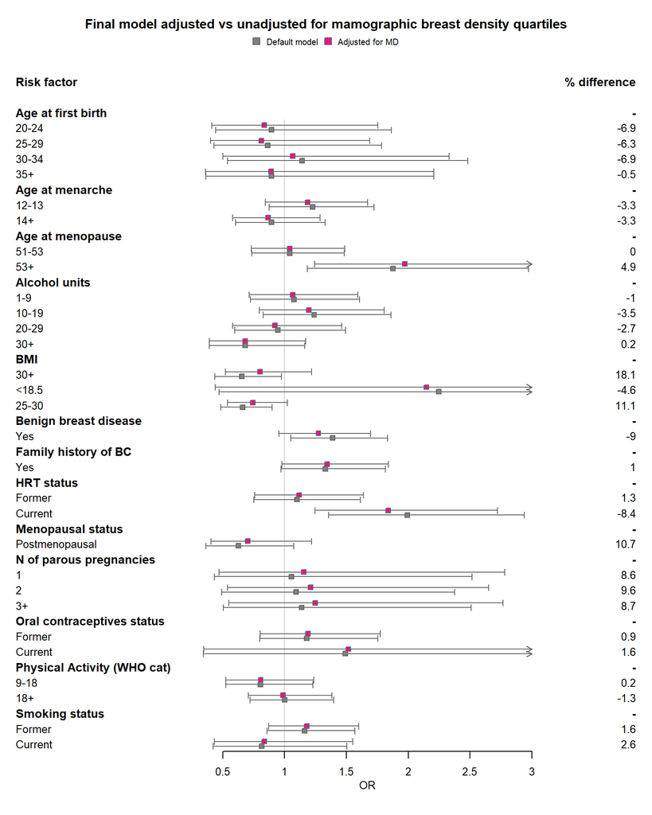

```r
is_summary <- is.na(md_forest_long$OR)


# develop forest

md_forest_long %>%
  group_by(mdl
           ) %>%
  mutate(mean = OR,
         lower = conf.low,
         upper = conf.high
         ) %>%
  forestplot(labeltext = c(level, pct_diff),
             xlog = FALSE,
             xlab = "OR",
             boxsize = 0.3,
             zero = 1,
             line.margin = 0.5,
             clip = c(0, 3),
             ticks = c(0, 0.5, 1, 1.5, 2, 2.5, 3),
             ci.vertices = T,
             ci.vertices.height = 0.2,
             legend = c("Default model", "Adjusted for MD"),
             title = paste("Final model adjusted vs unadjusted for mamographic breast density quartiles"),
             is.summary = is_summary
             ) %>%
  fp_set_style(box = c("grey50","deeppink2") %>%  lapply(function(x) gpar(fill = x, col = "#666666")),
               default = gpar(vertices = T),
               line = "grey40",
               summary = gpar(col = NA), # Set summary color to NA
               align = "lrrr",
               hrz_lines = gpar(col = NA), # Set line color to NA
               txt_gp = fpTxtGp(label = gpar(cex = 0.8),
                                    ticks = gpar(cex = 0.8),
                                    xlab = gpar(cex = 0.8),
                                )
               ) %>%
  fp_decorate_graph(graph.pos = 2
                    ) %>%
  fp_add_header(level = c("", "Risk factor"),
                pct_diff = c("", "% difference")
                ) %>%
  fp_insert_row(level = "",
                position = 3,
                mean = NULL,
                lower = NULL,
                upper = NULL,
                is.summary = TRUE,
                boxsize = NA)
```

#### 6.2.0.3 Continuous MD

```r
# Model 8b - with continuous MD ----------------------------------------------------------------
 # include parity and meno trick variable instead of original variables

# only included alcohol status - check if we need to do the trick if including both
# including "diagage", "d_R1toBC_y" - MD variables will be included in sub analysis

model <- df %>%
   filter(d_md_avail == 1 # include only those with md
         ) %>%
  drop_na(all_of(all_expl_variables_tr), diagage, d_R1toBC_y
           ) %>%
  glm(formula = d_dmode_n ~ d_R1menopause_lab3 + d_age_meno_tr_lab
      + d_R1hrt_tr_lab
      + d_parity_lab + d_agebirth1_tr_lab + d_age_menarche_lab + d_ocstatus_lab
      + d_bbd_lab + d_fambrca_lab
      + d_R1alcohol_units_lab + d_R1smokingstatus_lab
      + d_bmi_entry_lab + d_R1physmet_leis_who_lab
      + diagage + d_R1toBC_y + d_MDtoBC_y
      + d_md,
            family = binomial(link = "logit"))

model8b <- tbl_regression(model,
                         exponentiate = TRUE,
                         label = list(
                          d_R1alcohol_units_lab ~ "Alcohol units",
                          d_R1smokingstatus_lab ~ "Smoking status",
                          d_bmi_entry_lab ~ "BMI",
                          d_R1physmet_leis_who_lab ~ "Physical Activity (WHO cat)",
                          d_bbd_lab ~ "Benign breast disease",
                          d_fambrca_lab ~ "Family history of BC",
                          d_age_menarche_lab ~ "Age at menarche",
                          d_ocstatus_lab ~ "Oral contraceptives status",
                          d_R1menopause_lab3 ~ "Menopause",
                          d_age_meno_tr_lab ~ "Age at menopause",
                          d_R1hrt_tr_lab ~ "HRT status",
                          d_parity_lab ~ "N of parous pregnancies",
                          d_agebirth1_tr_lab ~ "Age at first birth",
                          d_md ~ "Mammographic breast density"
                         )
                         ) %>%
  add_global_p() %>%
  remove_row_type(variables = c(diagage, d_R1toBC_y, d_MDtoBC_y), # remove covariates
                  type = "all")

#model8b

# create a dataframe with broom::tidy() for forestplots

tidy_model8b <- model %>%
   tidy(exponentiate = TRUE, conf.int = TRUE) %>%
   mutate(OR = estimate) %>%
   select(-estimate) %>%
   select(term, OR, everything())
```

Table 4 including continuous MD

```r
table4b <- tbl_merge(
  tbls = list(descr_MDsubset, model6, model8b),
  tab_spanner = c("Subset of cases with MD", "Unadjusted for MD", "Adjusted for cont MD")
   )

#table4b

#  using gtsummary
table4b_diff <- table4b %>%
  modify_table_body(
    ~ .x %>%
      mutate(pct_diff = if_else(
          is.na(estimate_2) | is.na(estimate_3),
          "",
          sprintf("%.1f", (estimate_3 - estimate_2) / estimate_3 * 100))
    )
    ) %>%
  modify_header(
    pct_diff = "**Difference (%)**"
  )

table4b_diff
```

| **Characteristic** | Subset of cases with MD **I**, N = 401<sup>1</sup> | Subset of cases with MD **SD**, N = 790<sup>1</sup> | Unadjusted for MD **OR**<sup>2</sup> | Unadjusted for MD **95% CI**<sup>2</sup> | Unadjusted for MD **p-value** | Adjusted for cont MD **OR**<sup>2</sup> | Adjusted for cont MD **95% CI**<sup>2</sup> | Adjusted for cont MD **p-value** | **Difference (%)** |  |
| --- | --- | --- | --- | --- | --- | --- | --- | --- | --- | --- |
| Menopause |  |  |  |  | 0.091 |  |  | 0.2 |  |  |
| Premenopausal | 91 | 142 | — | — |  | — | — |  |  |  |
| Postmenopausal | 310 | 648 | 0.63 | 0.36, 1.08 |  | 0.71 | 0.41, 1.22 |  | 11.3 |  |
| N of parous pregnancies |  |  |  |  | >0.9 |  |  | >0.9 |  |  |
| 0 | 51 | 103 | — | — |  | — | — |  |  |  |
| 1 | 47 | 90 | 1.06 | 0.43, 2.52 |  | 1.21 | 0.49, 2.92 |  | 13.0 |  |
| 2 | 212 | 416 | 1.09 | 0.49, 2.38 |  | 1.28 | 0.57, 2.80 |  | 14.3 |  |
| 3+ | 91 | 181 | 1.14 | 0.51, 2.51 |  | 1.31 | 0.58, 2.91 |  | 13.2 |  |
| Age at menarche |  |  |  |  | 0.14 |  |  | 0.2 |  |  |
| <12 | 82 | 183 | — | — |  | — | — |  |  |  |
| 12-13 | 193 | 351 | 1.23 | 0.88, 1.72 |  | 1.18 | 0.84, 1.67 |  | -3.6 |  |
| 14+ | 86 | 191 | 0.89 | 0.60, 1.33 |  | 0.87 | 0.59, 1.30 |  | -2.4 |  |
| Unknown | 40 | 65 |  |  |  |  |  |  |  |  |
| Oral contraceptives status |  |  |  |  | 0.7 |  |  | 0.7 |  |  |
| Never | 56 | 145 | — | — |  | — | — |  |  |  |
| Former | 340 | 638 | 1.18 | 0.80, 1.75 |  | 1.17 | 0.79, 1.75 |  | -0.5 |  |
| Current | 4 | 6 | 1.49 | 0.34, 5.87 |  | 1.44 | 0.33, 5.72 |  | -3.5 |  |
| Unknown | 1 | 1 |  |  |  |  |  |  |  |  |
| Benign breast disease |  |  |  |  | 0.022 |  |  | 0.12 |  |  |
| No | 248 | 539 | — | — |  | — | — |  |  |  |
| Yes | 153 | 251 | 1.39 | 1.05, 1.83 |  | 1.26 | 0.95, 1.68 |  | -10.2 |  |
| Family history of BC |  |  |  |  | 0.075 |  |  | 0.066 |  |  |
| No | 302 | 621 | — | — |  | — | — |  |  |  |
| Yes | 99 | 169 | 1.33 | 0.97, 1.82 |  | 1.35 | 0.98, 1.84 |  | 1.2 |  |
| Alcohol units |  |  |  |  | 0.2 |  |  | 0.3 |  |  |
| 0 | 79 | 169 | — | — |  | — | — |  |  |  |
| 1-9 | 108 | 215 | 1.08 | 0.72, 1.61 |  | 1.07 | 0.71, 1.59 |  | -1.0 |  |
| 10-19 | 109 | 191 | 1.24 | 0.83, 1.86 |  | 1.20 | 0.80, 1.81 |  | -3.3 |  |
| 20-29 | 67 | 128 | 0.95 | 0.60, 1.49 |  | 0.93 | 0.58, 1.47 |  | -2.2 |  |
| 30+ | 38 | 87 | 0.68 | 0.39, 1.17 |  | 0.68 | 0.39, 1.18 |  | 0.5 |  |
| Smoking status |  |  |  |  | 0.4 |  |  | 0.4 |  |  |
| Never | 235 | 474 | — | — |  | — | — |  |  |  |
| Former | 150 | 265 | 1.16 | 0.86, 1.57 |  | 1.21 | 0.89, 1.64 |  | 3.7 |  |
| Current | 16 | 50 | 0.82 | 0.42, 1.50 |  | 0.84 | 0.44, 1.56 |  | 3.1 |  |
| Unknown | 0 | 1 |  |  |  |  |  |  |  |  |
| BMI |  |  |  |  | 0.016 |  |  | 0.3 |  |  |
| <18.5 | 4 | 3 | 2.25 | 0.47, 12.0 |  | 1.99 | 0.40, 11.0 |  | -12.8 |  |
| 18.5-25 | 225 | 347 | — | — |  | — | — |  |  |  |
| 25-30 | 111 | 276 | 0.66 | 0.49, 0.90 |  | 0.78 | 0.56, 1.07 |  | 14.6 |  |
| 30+ | 55 | 154 | 0.66 | 0.44, 0.97 |  | 0.84 | 0.54, 1.28 |  | 21.6 |  |
| Unknown | 6 | 10 |  |  |  |  |  |  |  |  |
| Physical Activity (WHO cat) |  |  |  |  | 0.5 |  |  | 0.5 |  |  |
| <9 | 87 | 180 | — | — |  | — | — |  |  |  |
| 9-18 | 70 | 157 | 0.81 | 0.53, 1.23 |  | 0.80 | 0.52, 1.23 |  | -0.5 |  |
| 18+ | 241 | 446 | 1.00 | 0.72, 1.40 |  | 0.97 | 0.70, 1.36 |  | -3.0 |  |
| Unknown | 3 | 7 |  |  |  |  |  |  |  |  |
| Mammographic breast density quartile |  |  |  |  |  |  |  |  |  |  |
| 1 | 73 | 225 |  |  |  |  |  |  |  |  |
| 2 | 96 | 202 |  |  |  |  |  |  |  |  |
| 3 | 105 | 193 |  |  |  |  |  |  |  |  |
| 4 | 127 | 170 |  |  |  |  |  |  |  |  |
| Age at menopause |  |  |  |  | 0.013 |  |  | 0.005 |  |  |
| <50 | 88 | 209 | — | — |  | — | — |  |  |  |
| 51-53 | 154 | 339 | 1.04 | 0.73, 1.48 |  | 1.02 | 0.72, 1.45 |  | -2.3 |  |
| 53+ | 67 | 96 | 1.88 | 1.19, 2.97 |  | 2.00 | 1.26, 3.19 |  | 6.2 |  |
| Pre-menopausal | 91 | 142 |  |  |  |  |  |  |  |  |
| Unknown | 1 | 4 |  |  |  |  |  |  |  |  |
| HRT status |  |  |  |  | <0.001 |  |  | 0.012 |  |  |
| Never | 112 | 272 | — | — |  | — | — |  |  |  |
| Former | 89 | 227 | 1.10 | 0.75, 1.61 |  | 1.11 | 0.76, 1.64 |  | 1.1 |  |
| Current | 107 | 147 | 1.99 | 1.36, 2.94 |  | 1.77 | 1.20, 2.63 |  | -12.6 |  |
| Pre-menopausal | 91 | 141 |  |  |  |  |  |  |  |  |
| Unknown | 2 | 3 |  |  |  |  |  |  |  |  |
| Age at first birth |  |  |  |  | 0.8 |  |  | 0.8 |  |  |
| <20 | 17 | 31 | — | — |  | — | — |  |  |  |
| 20-24 | 103 | 225 | 0.90 | 0.44, 1.87 |  | 0.82 | 0.40, 1.71 |  | -9.7 |  |
| 25-29 | 136 | 271 | 0.86 | 0.43, 1.79 |  | 0.80 | 0.40, 1.66 |  | -8.2 |  |
| 30-34 | 67 | 112 | 1.14 | 0.54, 2.48 |  | 1.04 | 0.49, 2.28 |  | -9.3 |  |
| 35+ | 25 | 44 | 0.90 | 0.37, 2.21 |  | 0.85 | 0.35, 2.12 |  | -4.9 |  |
| Non-parous | 51 | 103 |  |  |  |  |  |  |  |  |
| Unknown | 2 | 4 |  |  |  |  |  |  |  |  |
| Mammographic breast density |  |  |  |  |  | 1.02 | 1.01, 1.03 | <0.001 |  |  |

<sup>1</sup> n  
<sup>2</sup> OR = Odds Ratio, CI = Confidence Interval

#### 6.2.0.4 Forest plot with continuous MD

```r
# full join data from both models
md_forest_df <- tidy_model6 %>%
  full_join(tidy_model8b, by = "term", suffix = c("_mdl6", "_mdl8"))

# RESUME HERE
# create labels and variable names structures
md_forest_df <- md_forest_df %>%
  mutate(variable = case_when(
    grepl("menopause", term) ~ "Menopausal status",
    grepl("age_meno", term) ~ "Age at menopause",
    grepl("hrt", term) ~ "HRT status",
    grepl("parity", term) ~ "N of parous pregnancies",
    grepl("agebirth1", term) ~ "Age at first birth",
    grepl("age_menarche", term) ~ "Age at menarche",
    grepl("ocstatus", term) ~ "Oral contraceptives status",
    grepl("bbd", term) ~ "Benign breast disease",
    grepl("fambrca", term) ~ "Family history of BC",
    grepl("R1alcohol", term) ~ "Alcohol units",
    grepl("R1smokingstatus", term) ~ "Smoking status",
    grepl("bmi_entry", term) ~ "BMI",
    grepl("R1physmet_leis_who", term) ~ "Physical Activity (WHO cat)",
    grepl("md", term) ~ "Mammographic breast density"
                              ),
    level = case_when(
      grepl("d_R1menopause_lab3", term) ~ sub("d_R1menopause_lab3", "", term),
      grepl("age_meno", term) ~ sub("d_age_meno_tr_lab", "", term),
      grepl("hrt", term) ~ sub("d_R1hrt_tr_lab", "", term),
      grepl("parity", term) ~ sub("d_parity_lab", "", term),
      grepl("agebirth1", term) ~ sub("d_agebirth1_tr_lab", "", term),
      grepl("age_menarche", term) ~ sub("d_age_menarche_lab", "", term),
      grepl("ocstatus", term) ~ sub("d_ocstatus_lab", "", term),
      grepl("bbd", term) ~ sub("d_bbd_lab", "", term),
      grepl("fambrca", term) ~ sub("d_fambrca_lab", "", term),
      grepl("R1alcohol", term) ~ sub("d_R1alcohol_units_lab", "", term),
      grepl("R1smokingstatus", term) ~ sub("d_R1smokingstatus_lab", "", term),
      grepl("bmi_entry", term) ~ sub("d_bmi_entry_lab", "", term),
      grepl("R1physmet_leis_who", term) ~ sub("d_R1physmet_leis_who_lab", "", term),
      grepl("md", term) ~ sub("d_md", "", term)
    )
    )

# add subheading rows

subheading_data <- md_forest_df %>%
  distinct(variable) %>%
  mutate(level = variable)

md_forest_df <- bind_rows(subheading_data, md_forest_df) %>%
  arrange(variable, factor(level, levels = unique(level)))



# create long format
md_forest_long <- md_forest_df %>%
  filter(!term %in% c("(Intercept)", "diagage", "d_R1toBC_y", "d_MDtoBC_y", "d_md"),
         !is.na(level),
         ) %>%
  select(level, OR_mdl6, conf.low_mdl6, conf.high_mdl6, OR_mdl8, conf.low_mdl8, conf.high_mdl8
         ) %>%
  mutate(pct_diff = if_else(is.na(OR_mdl6), "-", as.character(round((OR_mdl8 - OR_mdl6) / OR_mdl8 * 100, 1)))
         ) %>%
  pivot_longer(
    cols = c(OR_mdl6, conf.low_mdl6, conf.high_mdl6,
             OR_mdl8, conf.low_mdl8, conf.high_mdl8
             ),
    names_to = c(".value", "mdl"),
    names_sep = "_"
  )
```

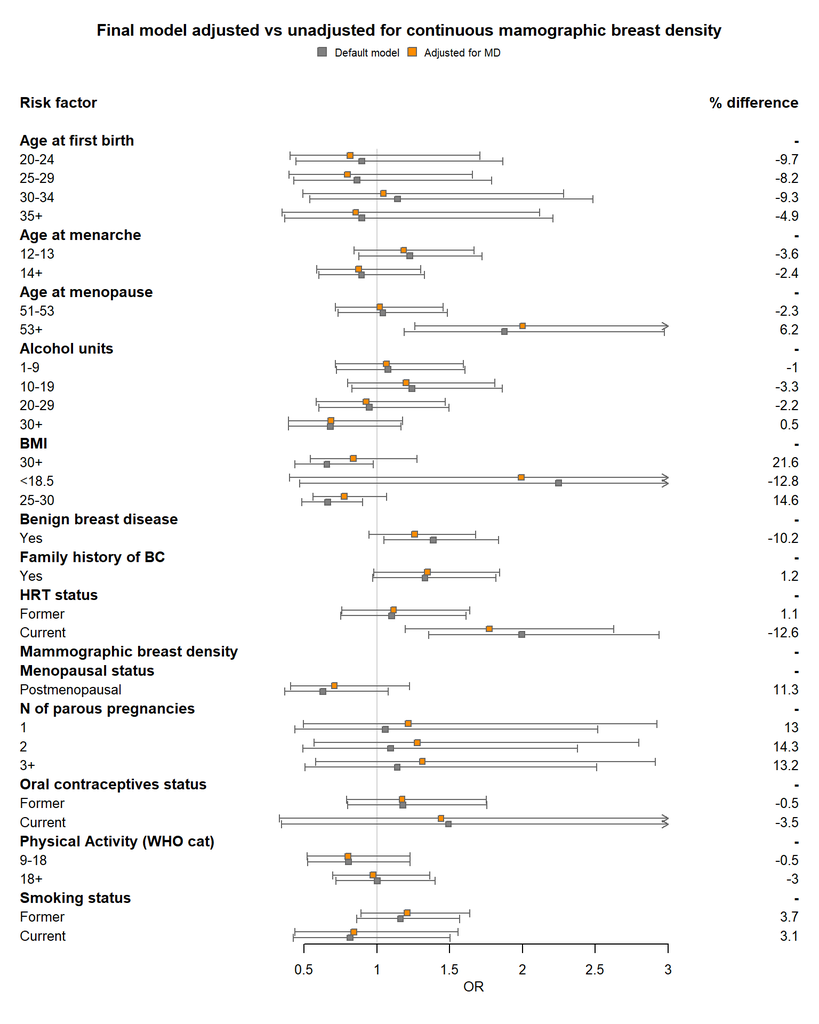

```r
is_summary <- is.na(md_forest_long$OR)


# develop forest

md_forest_long %>%
  group_by(mdl
           ) %>%
  mutate(mean = OR,
         lower = conf.low,
         upper = conf.high
         ) %>%
  forestplot(labeltext = c(level, pct_diff),
             xlog = FALSE,
             xlab = "OR",
             boxsize = 0.3,
             zero = 1,
             line.margin = 0.5,
             clip = c(0, 3),
             ticks = c(0, 0.5, 1, 1.5, 2, 2.5, 3),
             ci.vertices = T,
             ci.vertices.height = 0.2,
             legend = c("Default model", "Adjusted for MD"),
             title = paste("Final model adjusted vs unadjusted for continuous mamographic breast density"),
             is.summary = is_summary
             ) %>%
  fp_set_style(box = c("grey50","darkorange") %>%  lapply(function(x) gpar(fill = x, col = "#666666")),
               default = gpar(vertices = T),
               line = "grey40",
               summary = gpar(col = NA), # Set summary color to NA
               align = "lrrr",
               hrz_lines = gpar(col = NA), # Set line color to NA
               txt_gp = fpTxtGp(label = gpar(cex = 0.8),
                                    ticks = gpar(cex = 0.8),
                                    xlab = gpar(cex = 0.8)
                                )
               ) %>%
  fp_decorate_graph(graph.pos = 2
                    ) %>%
  fp_add_header(level = c("", "Risk factor"),
                pct_diff = c("", "% difference")
                ) %>%
  fp_insert_row(level = "",
                position = 3,
                mean = NULL,
                lower = NULL,
                upper = NULL,
                is.summary = TRUE,
                boxsize = NA)
```

## 6.3 ST 2 - TC descriptives by detection mode with logistic regression results

Similar to table 3 but with TC instead of risk factors

```r
# summary Logistic Regression of Model 10  -----------------------------------------



# remove columns with total and interval N - not simple with gtsummary, trying from scratch without adding the columns


# Create clean version of logistic output, without Ns

model <- df %>%
  drop_na(all_of(tumour_char_tr), diagage, d_R1toBC_y
           ) %>%
  glm(formula = d_dmode_n ~
      diagage + d_R1toBC_y
      + d_inv_status + d_grade_tr + d_morph4_tr_lab + d_pos_nodes_tr_lab
      + d_tmsize_tr_lab + d_er_tr_lab + d_pr_tr_lab + d_her2_tr_lab,
            family = binomial(link = "logit"))

# tidy up output
model10 <- tbl_regression(model,
                         exponentiate = TRUE,
                         label = list(
                          d_inv_status ~ "Invasive status",
                          d_grade_tr ~ "Grade",
                          d_morph4_tr_lab ~ "Morphology type",
                          d_pos_nodes_tr_lab ~ "Positive nodes",
                          d_tmsize_tr_lab ~ "Tumour size",
                          d_er_tr_lab ~ "ER status",
                          d_pr_tr_lab ~ "PR status",
                          d_her2_tr_lab ~ "HER2 status"
                         )
                         ) %>%
  add_global_p() %>%
  remove_row_type(variables = c(diagage, d_R1toBC_y), # remove covariates
                  type = "all")


#model10




# Create descriptives by mode of detection ------------------------------------
# select(d_dmode_n, d_R1alcohol_units_lab, d_R1smokingstatus_lab, d_bmi_entry_lab,  d_R1physmet_leis_who_lab, d_bbd_lab, d_fambrca_lab, d_age_menarche_lab, d_ocstatus_lab, d_R1menopause_lab3, d_age_meno_tr_lab, d_R1hrt_tr_lab, d_parity_tr_lab, d_agebirth1_tr_lab)

# note: need to rename the non-trick variables according to their trick name to align with the model, which can then allow table merge.

# include missing
# create df

descr_model10_df <- df %>%
  select(d_dmode, all_of(tumour_char), diagage, d_R1toBC_y
         ) %>%
  mutate(d_grade_lab = as.character(if_else(d_grade_lab == "DCIS", NA, d_grade_lab)) # recode dcis to missing
  ) %>%
  mutate(d_grade_lab = factor(x = d_grade_lab,
                              levels = c(1, 2, 3))
         ) %>%
  mutate(d_grade_tr = d_grade_lab,
         d_morph4_tr_lab = d_morph4_lab,
         d_pos_nodes_tr_lab = d_pos_nodes_lab,
         d_tmsize_tr_lab = d_tumour_size_lab,
         d_er_tr_lab = d_er_status_lab,
         d_pr_tr_lab = d_pr_status_lab,
         d_her2_tr_lab = d_her2_status_lab
         ) %>%
  select(-d_grade_lab, -d_morph4_lab, -d_pos_nodes_lab, -d_tumour_size_lab, -d_er_status_lab, -d_pr_status_lab, -d_her2_status_lab, -diagage, -d_R1toBC_y)



# glimpse(descr_model2)
# str(test)

# create gs summary table
descr_model10 <- descr_model10_df %>%
  tbl_summary(by = d_dmode,
              statistic = list(
                all_continuous() ~ "{mean} ({sd})",
                all_categorical() ~ "{n} ({p})"
                ),
              digits = all_continuous() ~ 2,
              label = list(
                          d_inv_status ~ "Invasive status",
                          d_grade_tr ~ "Grade",
                          d_morph4_tr_lab ~ "Morphology type",
                          d_pos_nodes_tr_lab ~ "Positive nodes",
                          d_tmsize_tr_lab ~ "Tumour size",
                          d_er_tr_lab ~ "ER status",
                          d_pr_tr_lab ~ "PR status",
                          d_her2_tr_lab ~ "HER2 status"
                         )
              ) %>%
  add_overall()

#descr_model10

# merge with analysis output -------------------------------------------------


ST2 <- tbl_merge(
  tbls = list(descr_model10, model10),
  tab_spanner = c("", "")
   )




ST2
```

| **Characteristic** | **Overall**, N = 1,940<sup>1</sup> | **I**, N = 755<sup>1</sup> | **SD**, N = 1,185<sup>1</sup> | **OR**<sup>2</sup> | **95% CI**<sup>2</sup> | **p-value** |
| --- | --- | --- | --- | --- | --- | --- |
| Invasive status |  |  |  |  |  | 0.14 |
| 1 | 1,632 (84) | 708 (94) | 924 (78) | — | — |  |
| 0 | 308 (16) | 47 (6.2) | 261 (22) | 0.56 | 0.26, 1.20 |  |
| Grade |  |  |  |  |  | <0.001 |
| 1 | 338 (21) | 88 (13) | 250 (27) | — | — |  |
| 2 | 812 (51) | 335 (49) | 477 (52) | 1.23 | 0.76, 2.04 |  |
| 3 | 451 (28) | 264 (38) | 187 (20) | 2.59 | 1.46, 4.66 |  |
| Unknown | 339 | 68 | 271 |  |  |  |
| Morphology type |  |  |  |  |  | 0.4 |
| Ductal | 1,247 (76) | 549 (78) | 698 (76) | — | — |  |
| Lobular | 214 (13) | 95 (13) | 119 (13) | 0.94 | 0.54, 1.63 |  |
| Mixed: ductal and other | 68 (4.2) | 25 (3.5) | 43 (4.7) | 1.27 | 0.59, 2.72 |  |
| Other | 103 (6.3) | 39 (5.5) | 64 (6.9) | 0.54 | 0.22, 1.21 |  |
| Unknown | 308 | 47 | 261 |  |  |  |
| Positive nodes |  |  |  |  |  | 0.003 |
| Negative | 905 (68) | 304 (57) | 601 (76) | — | — |  |
| Positive | 428 (32) | 234 (43) | 194 (24) | 1.74 | 1.20, 2.53 |  |
| Unknown | 607 | 217 | 390 |  |  |  |
| Tumour size |  |  |  |  |  | 0.007 |
| <21 | 992 (70) | 336 (57) | 656 (79) | — | — |  |
| 21-50 | 387 (27) | 225 (38) | 162 (19) | 1.86 | 1.26, 2.76 |  |
| 50+ | 46 (3.2) | 31 (5.2) | 15 (1.8) | 1.76 | 0.73, 4.40 |  |
| Unknown | 515 | 163 | 352 |  |  |  |
| ER status |  |  |  |  |  | 0.5 |
| Positive | 1,316 (85) | 525 (79) | 791 (90) | — | — |  |
| Negative | 224 (15) | 137 (21) | 87 (9.9) | 1.23 | 0.69, 2.19 |  |
| Unknown | 400 | 93 | 307 |  |  |  |
| PR status |  |  |  |  |  | >0.9 |
| Positive | 658 (67) | 283 (62) | 375 (71) | — | — |  |
| Negative | 329 (33) | 175 (38) | 154 (29) | 0.99 | 0.62, 1.56 |  |
| Unknown | 953 | 297 | 656 |  |  |  |
| HER2 status |  |  |  |  |  | 0.7 |
| Positive | 194 (13) | 102 (16) | 92 (11) | — | — |  |
| Negative | 1,249 (87) | 524 (84) | 725 (89) | 1.13 | 0.66, 1.93 |  |
| Unknown | 497 | 129 | 368 |  |  |  |

<sup>1</sup> n (%)  
<sup>2</sup> OR = Odds Ratio, CI = Confidence Interval

```r
# this ID is extra in the LR output from model 2 - T276E210
# this is because HRT status was missing as under 50 but it is present in trick hrt as recoded to never. - check what to do with this
```

## 6.4 ST 3 - Risk factor analysis adjusted for tumour characteristics (sensitivity analysis) - on subset of cases with TC

using model 3 (default model on subset of cases with tumour characteristics) and model 4 (adjusting for TC)

similar layout to table 4

```r
# Model 3 - subset on those with TC----------------------------------------------------------------
 # include parity and meno trick variable instead of original variables

# only included alcohol status - check if we need to do the trick if including both
# including "diagage", "d_R1toBC_y" - MD variables will be included in sub analysis

 model <- df %>%
   tidyr::drop_na(all_of(tumour_char_tr), all_of(all_expl_variables_tr), diagage, d_R1toBC_y
           ) %>%
  glm(formula = d_dmode_n ~ d_R1menopause_lab3 + d_age_meno_tr_lab
      + d_R1hrt_tr_lab
      + d_parity_lab + d_agebirth1_tr_lab + d_age_menarche_lab + d_ocstatus_lab
      + d_bbd_lab + d_fambrca_lab
      + d_R1alcohol_units_lab + d_R1smokingstatus_lab
      + d_bmi_entry_lab + d_R1physmet_leis_who_lab
      + diagage + d_R1toBC_y,
            family = binomial(link = "logit"))

# tidy up output
model3 <- tbl_regression(model,
                         exponentiate = TRUE,
                         label = list(
                          d_R1alcohol_units_lab ~ "Alcohol units",
                          d_R1smokingstatus_lab ~ "Smoking status",
                          d_bmi_entry_lab ~ "BMI",
                          d_R1physmet_leis_who_lab ~ "Physical Activity (WHO cat)",
                          d_bbd_lab ~ "Benign breast disease",
                          d_fambrca_lab ~ "Family history of BC",
                          d_age_menarche_lab ~ "Age at menarche",
                          d_ocstatus_lab ~ "Oral contraceptives status",
                          d_R1menopause_lab3 ~ "Menopause",
                          d_age_meno_tr_lab ~ "Age at menopause",
                          d_R1hrt_tr_lab ~ "HRT status",
                          d_parity_lab ~ "N of parous pregnancies",
                          d_agebirth1_tr_lab ~ "Age at first birth"
                         )
                         ) %>%
  add_global_p() %>%
  remove_row_type(variables = c(diagage, d_R1toBC_y), # remove covariates
                  type = "all")


model3a <- tbl_regression(model, exponentiate = TRUE) %>%
  add_n(location = "level")  %>%
  add_nevent(location = "level") %>%
  add_global_p() %>%
  modify_header(stat_nevent = "**Interval N**",
                stat_n = "**Total N**")



#model3
#model3a

# create a dataframe with broom::tidy() for forestplots

tidy_model3 <- model %>%
   tidy(exponentiate = TRUE, conf.int = TRUE) %>%
   mutate(OR = estimate) %>%
   select(-estimate) %>%
   select(term, OR, everything())
#tidy_model3


# Model 4 ----------------------------------------------------------------
 # include parity and meno trick variable instead of original variables

# only included alcohol status - check if we need to do the trick if including both
# including "diagage", "d_R1toBC_y" - MD variables will be included in sub analysis

model <- df %>%
   tidyr::drop_na(all_of(tumour_char_tr), all_of(all_expl_variables_tr), diagage, d_R1toBC_y
           ) %>%
  glm(formula = d_dmode_n ~ d_R1menopause_lab3 + d_age_meno_tr_lab
      + d_R1hrt_tr_lab
      + d_parity_lab + d_agebirth1_tr_lab + d_age_menarche_lab + d_ocstatus_lab
      + d_bbd_lab + d_fambrca_lab
      + d_R1alcohol_units_lab + d_R1smokingstatus_lab
      + d_bmi_entry_lab + d_R1physmet_leis_who_lab
      + diagage + d_R1toBC_y
      + d_inv_status + d_grade_tr + d_morph4_tr_lab + d_pos_nodes_tr_lab
      + d_tmsize_tr_lab + d_er_tr_lab + d_pr_tr_lab + d_her2_tr_lab,
            family = binomial(link = "logit"))

model4 <- tbl_regression(model,
                         exponentiate = TRUE,
                         label = list(
                          d_R1alcohol_units_lab ~ "Alcohol units",
                          d_R1smokingstatus_lab ~ "Smoking status",
                          d_bmi_entry_lab ~ "BMI",
                          d_R1physmet_leis_who_lab ~ "Physical Activity (WHO cat)",
                          d_bbd_lab ~ "Benign breast disease",
                          d_fambrca_lab ~ "Family history of BC",
                          d_age_menarche_lab ~ "Age at menarche",
                          d_ocstatus_lab ~ "Oral contraceptives status",
                          d_R1menopause_lab3 ~ "Menopause",
                          d_age_meno_tr_lab ~ "Age at menopause",
                          d_R1hrt_tr_lab ~ "HRT status",
                          d_parity_lab ~ "N of parous pregnancies",
                          d_agebirth1_tr_lab ~ "Age at first birth",
                          d_inv_status ~ "Invasive status",
                          d_grade_tr ~ "Grade",
                          d_morph4_tr_lab ~ "Morphology type",
                          d_pos_nodes_tr_lab ~ "Positive nodes",
                          d_tmsize_tr_lab ~ "Tumour size",
                          d_er_tr_lab ~ "ER status",
                          d_pr_tr_lab ~ "PR status",
                          d_her2_tr_lab ~ "HER2 status"
                         )
                         ) %>%
  add_global_p() %>%
  remove_row_type(variables = c(diagage, d_R1toBC_y), # remove covariates
                  type = "all")

# model4
#
 model4a <- tbl_regression(model, exponentiate = TRUE) %>%
  add_n(location = "level")  %>%
   add_nevent(location = "level") %>%
   add_global_p() %>%
   modify_header(stat_nevent = "**Interval N**",
                 stat_n = "**Total N**")

# model4a
# model3a


# create a dataframe with broom::tidy() for forestplots

tidy_model4 <- model %>%
   tidy(exponentiate = TRUE, conf.int = TRUE) %>%
   mutate(OR = estimate) %>%
   select(-estimate) %>%
   select(term, OR, everything())


 # Descriptives for model 4 -------------------------------------------------
# subset on those with mammo density


descr_TCsubset_df <- df %>%
  select(d_dmode,  all_of(all_expl_variables_tr), all_of(all_expl_variables), all_of(tumour_char_tr), all_of(tumour_char), diagage, d_R1toBC_y) %>%
  tidyr::drop_na(all_of(tumour_char_tr), all_of(all_expl_variables_tr), diagage, d_R1toBC_y
  ) %>%
  mutate(d_bmi_entry_lab = fct_relevel(d_bmi_entry_lab, "<18.5", "18.5-25", "25-30", "30+")
              ) %>%
  # recode the names of normal variables to trick to allow merge between regression tables and this descriptive table
  mutate(d_age_meno_tr_lab = d_age_menopause_lab,
         d_R1hrt_tr_lab = d_R1hrtstatus_lab,
         d_agebirth1_tr_lab = d_agebirth1_lab,
         d_grade_tr = d_grade_lab,
         d_morph4_tr_lab = d_morph4_lab,
         d_pos_nodes_tr_lab = d_pos_nodes_lab,
         d_tmsize_tr_lab = d_tumour_size_lab,
         d_er_tr_lab = d_er_status_lab,
         d_pr_tr_lab = d_pr_status_lab,
         d_her2_tr_lab = d_her2_status_lab
         ) %>%
  select(-d_age_menopause_lab, -d_R1hrtstatus_lab, -d_agebirth1_lab, -diagage, -d_R1toBC_y, -d_grade_lab, -d_morph4_lab, -d_pos_nodes_lab, -d_tumour_size_lab, -d_er_status_lab, -d_pr_status_lab, -d_her2_status_lab)



# glimpse(descr_MDsubset_df)
# str(descr_MDsubset_df)

# create gs summary table
descr_TCsubset <- descr_TCsubset_df %>%
  tbl_summary(by = d_dmode,
              statistic = list(
                all_continuous() ~ "{mean} ({sd})",
                all_categorical() ~ "{n} ({p})"
                ),
              digits = all_continuous() ~ 2,
              label = list(
                          d_R1alcohol_units_lab ~ "Alcohol units",
                          d_R1smokingstatus_lab ~ "Smoking status",
                          d_bmi_entry_lab ~ "BMI",
                          d_R1physmet_leis_who_lab ~ "Physical Activity (WHO cat)",
                          d_bbd_lab ~ "Benign breast disease",
                          d_fambrca_lab ~ "Family history of BC",
                          d_age_menarche_lab ~ "Age at menarche",
                          d_ocstatus_lab ~ "Oral contraceptives status",
                          d_R1menopause_lab3 ~ "Menopause",
                          d_age_meno_tr_lab ~ "Age at menopause",
                          d_R1hrt_tr_lab ~ "HRT status",
                          d_parity_lab ~ "N of parous pregnancies",
                          d_agebirth1_tr_lab ~ "Age at first birth",
                          d_inv_status ~ "Invasive status",
                          d_grade_tr ~ "Grade",
                          d_morph4_tr_lab ~ "Morphology type",
                          d_pos_nodes_tr_lab ~ "Positive nodes",
                          d_tmsize_tr_lab ~ "Tumour size",
                          d_er_tr_lab ~ "ER status",
                          d_pr_tr_lab ~ "PR status",
                          d_her2_tr_lab ~ "HER2 status"
                ),
              type = list(d_bbd_lab ~ "categorical",
                          d_fambrca_lab ~ "categorical")
              ) #%>%
  #add_overall()


#descr_TCsubset
# check numbers against
# model4a
# model3a



# merge tables -------------------------------------------------


ST3 <- tbl_merge(
  tbls = list(descr_TCsubset, model3, model4),
  tab_spanner = c("Subset with TC" ,"Unadjusted for TC", "Adjusted for TC")
   )


#ST3


# adding pct difference -------------------------------------------

#  using gtsummary
ST3_diff <- ST3 %>%
  modify_table_body(
    ~ .x %>%
      mutate(pct_diff = if_else(
          is.na(estimate_2) | is.na(estimate_3),
          "",
          sprintf("%.1f", (estimate_3 - estimate_2) / estimate_3 * 100))
    )
    ) %>%
  modify_header(
    pct_diff = "**Difference (%)**"
  )

ST3_diff
```

| **Characteristic** | Subset with TC **I**, N = 298<sup>1</sup> | Subset with TC **SD**, N = 558<sup>1</sup> | Unadjusted for TC **OR**<sup>2</sup> | Unadjusted for TC **95% CI**<sup>2</sup> | Unadjusted for TC **p-value** | Adjusted for TC **OR**<sup>2</sup> | Adjusted for TC **95% CI**<sup>2</sup> | Adjusted for TC **p-value** | **Difference (%)** |  |
| --- | --- | --- | --- | --- | --- | --- | --- | --- | --- | --- |
| Menopause |  |  |  |  | 0.4 |  |  | 0.7 |  |  |
| Premenopausal | 96 (32) | 168 (30) | — | — |  | — | — |  |  |  |
| Postmenopausal | 202 (68) | 390 (70) | 0.77 | 0.43, 1.37 |  | 0.87 | 0.45, 1.67 |  | 11.4 |  |
| Age at menopause |  |  |  |  | 0.11 |  |  | 0.075 |  |  |
| <50 | 64 (21) | 133 (24) | — | — |  | — | — |  |  |  |
| 51-53 | 98 (33) | 198 (35) | 0.94 | 0.63, 1.41 |  | 0.82 | 0.53, 1.29 |  | -14.0 |  |
| 53+ | 40 (13) | 59 (11) | 1.62 | 0.94, 2.80 |  | 1.62 | 0.88, 3.00 |  | 0.3 |  |
| Pre-menopausal | 96 (32) | 168 (30) |  |  |  |  |  |  |  |  |
| HRT status |  |  |  |  | 0.023 |  |  | 0.018 |  |  |
| Never | 75 (25) | 165 (30) | — | — |  | — | — |  |  |  |
| Former | 59 (20) | 137 (25) | 1.01 | 0.64, 1.60 |  | 1.03 | 0.62, 1.71 |  | 2.2 |  |
| Current | 68 (23) | 88 (16) | 1.76 | 1.12, 2.79 |  | 1.95 | 1.18, 3.25 |  | 9.7 |  |
| Pre-menopausal | 96 (32) | 168 (30) |  |  |  |  |  |  |  |  |
| N of parous pregnancies |  |  |  |  | 0.8 |  |  | 0.7 |  |  |
| 0 | 39 (13) | 77 (14) | — | — |  | — | — |  |  |  |
| 1 | 33 (11) | 59 (11) | 1.42 | 0.55, 3.64 |  | 1.32 | 0.45, 3.78 |  | -8.1 |  |
| 2 | 156 (52) | 295 (53) | 1.38 | 0.60, 3.13 |  | 1.08 | 0.42, 2.71 |  | -27.9 |  |
| 3+ | 70 (23) | 127 (23) | 1.46 | 0.63, 3.39 |  | 1.33 | 0.52, 3.39 |  | -10.1 |  |
| Age at menarche |  |  |  |  | 0.2 |  |  | 0.4 |  |  |
| <12 | 68 (23) | 130 (23) | — | — |  | — | — |  |  |  |
| 12-13 | 155 (52) | 270 (48) | 1.11 | 0.76, 1.62 |  | 1.10 | 0.72, 1.70 |  | -0.4 |  |
| 14+ | 75 (25) | 158 (28) | 0.80 | 0.52, 1.24 |  | 0.85 | 0.52, 1.38 |  | 5.3 |  |
| Oral contraceptives status |  |  |  |  | 0.3 |  |  | 0.3 |  |  |
| Never | 24 (8.1) | 71 (13) | — | — |  | — | — |  |  |  |
| Former | 267 (90) | 476 (85) | 1.48 | 0.88, 2.56 |  | 1.61 | 0.90, 2.92 |  | 7.8 |  |
| Current | 7 (2.3) | 11 (2.0) | 1.83 | 0.56, 5.71 |  | 1.45 | 0.38, 5.27 |  | -25.9 |  |
| Benign breast disease |  |  |  |  | 0.052 |  |  | <0.001 |  |  |
| No | 179 (60) | 379 (68) | — | — |  | — | — |  |  |  |
| Yes | 119 (40) | 179 (32) | 1.36 | 1.00, 1.86 |  | 1.82 | 1.28, 2.59 |  | 25.3 |  |
| Family history of BC |  |  |  |  | 0.018 |  |  | 0.006 |  |  |

[output cut: 63 more lines]

<sup>1</sup> n (%)  
<sup>2</sup> OR = Odds Ratio, CI = Confidence Interval